# Analiza ofert sprzedaży mieszkań w Białymstoku

autor: Maciej Baranowski  
data: 23.04.2024

## Spis treści

1. Metodologia badania  
1.1 Cel i przedmiot badania  
1.2 Dane  
1.3 Hipotezy badawcze  
1.4 Pytania badawcze  
2. Wczytanie oraz przygotowanie danych  
2.1 Wczytanie bibliotek oraz danych  
2.2 Przygotowanie danych  
2.3 Eksploracja zmiennych kategorycznych  
2.4 Eksploracja zmiennych numerycznych  
2.5 Przygotowanie dodatkowych zmiennych  
3. Analiza ogłoszeń sprzedaży mieszkań w Białymstoku  
3.1 Charakterystyka ogłoszeń ze względu na zmienne numeryczne  
3.2 Charakterystyka przeciętnej ceny mieszkania ze względu na zmienne kategoryczne  
3.2.1 Typ rynku - rynek pierwotny vs. rynek wtórny  
3.2.2 Status ogłoszeniodawcy - typ podmiotu wystawiającego ogłoszenie (firma vs. osoba prywatna))  
3.2.3 Status mieszkania  
3.2.4 Miejscowość  
3.2.5 Dzielnica miasta  
3.3 Analiza przeciętnej ceny metra kwadratowego ze względu na położenie oraz typ mieszkania  
3.3.1 Typ rynku, typ ogłoszeniodawcy, typ mieszkania  
3.3.2 Typ rynku vs. typ ogłoszeniodawcy i status mieszkania ze wzglęu na położenie  
3.4 Przeciętna cena metra kwadratowego a wielkość sprzedawanego mieszkania  
3.4.1 Przeciętna wartość mieszkania ze względu na kategorię powierzchni  
3.4.2 Przeciętna cena za metr kwadratowy a powierzchnia oraz umiejscowienie sprzedawanego mieszkania  
3.4.3 Przeciętna cena mieszkania za metr kwadratowy ze względu na typ oraz dzielnicę miasta  
3.4.3.1 Kawalerki  
3.4.3.2 Mieszkania średnie  
3.4.3.3 Mieszkania duże  
3.5 Dodatkowe cechy mieszkań na sprzedaż  
3.6 Wpływ poszczególnych cech na wartość mieszkania (przeciętna cena za metr kwadratowy))  
3.6.1 Braki w danych  
3.6.2 Wpływ zmiennych na cenę mieszkania - analiza korelacji  
3.6.3 Podsumowanie analizy korelacji  
4. Podsumowanie badania  
4.1 Dzielnica  
4.2 Powierzchnia  
4.3 Rynek pierwotny vs rynek wtórny, a status mieszkania oraz wiek budynku  
4.4 Pozostałe zmienne  
4.5 Liczba ogłoszeń  
5. Zakończenie

## 1. Metodologia badania

Powrót do początku

### 1.1 Cel i przedmiot badania

Celem badania jest przeanalizowanie sytuacji mieszkaniowej panującej w mieście Białystok i jego okolicy (miejscowości w promieniu do 50 km od miasta) oraz sprawdzeniu, które z cech mieszkań wystawianychń w ogłoszeniach w serwisie Otodom mogą wpływać na zmianę ceny mieszkania. Charakterystyka sytuacji ogłoszeń na sprzedaż mieszkań w Białymstoku może pomóc w wyborze potencjalnego mieszkania do zakupu oraz wpłynąć na świadomosć użytkownika serwisu Oto Dom, na które zmienne warto jest zwracać szczególną uwagę przy poszukiwaniach mieszkania pod zakup.

Analiza obejmuje jedynie ogłoszenia dotyczące sprzedaży mieszkań. Białystok jest miastem w którym również występuje zabudowa w postaci domów jednorodzinnych, jednakże w ostatnich latach w mieście obserwuje się wzmożone budownictwo bloków. Na zakup domu mogą wpływać zupełnie inne czynniki niż na zakup mieszkań. Osoby zainteresowane domem jednorodzinnym potencjalnie mogą również bardziej interesować się wolną działką na której mogą wybudować dom wg własnego projektu. W serwisie Otodom są również dostępne mieszkania budowane przez deweloperów, co umożliwia również analizę porównawczą pomiędzy rynkiem pierwotnym, a wtórnym w mieście Białystok.

Jako wartość porównania ceny w badaniu wzięto cenę za metr kwadratowy. Jest to najbardziej optymalny wskaźnik porówawczy ceny mieszkań różnego typu.

### 1.2 Dane

Dane zostały pobrane z serwisu Otodom w lutym 2024 roku za pomocą skryptu napisanego przez autora analizy (udostępnionego na portalu github: https://github.com/baranowskimac/analiza_ofert_sprzedazy_mieszkan_Bialystok_022024). Przeanalizowano 1877 unikalnych ofert sprzedaży mieszkań, które znajdują się w Białymstoku lub w okolicach miasta (w promieniu do 50 km).

### 1.3 Hipotezy badawcze

1. Przeciętna cena mieszkania za metr kwadratowy różni się z względu na:
   - położenie mieszkania
   - wielkość mieszkania
   - podmiot wystawiający mieszkanie na sprzedaż
   - pochodzenie mieszkania (rynek pierwotny vs. rynek wtórny)
   - dodatkowe cechy, które są dostępne w danej ofercie tj:
     - dodatkow wyposażenie mieszkania
       - piekarnik
       - kuchenka
       - telefon
       - meble
       - zmywarka
       - pralka
       - lodówka
       - telewizor
     - dodatkowe pomieszczenia przypisane do mieszkania
       - garaż lub miejsce parkingowe
       - dodatkowe pomieszczenie użytkowe
       - ogródek
       - piwnica
       - taras
     - udogodnienia:
       - winda
       - klimatyzacja
     - dodatkowe cechy mieszkania:
       - balkon
       - oddzielna kuchnia
     - media
       - telewizja kablowa
       - internet
     - bezpieczeństwo
       - system alarmowy
       - położenie mieszkania na terenie zamkniętym
       - monitoring bądź ochrona osiedla na którym znajduje się mieszkanie
       - drzwy antywłamaniowe na wyposażeniu
       - domofon
       - rolety antywłamaniowe na wyposażeniu

### 1.4 Pytania badawcze

1. Jaka jest przeciętna cena za metr kwadratowy mieszkania w Białymstoku?
2. Czy przeciętna centa za metr kwadratowy różni się ze względu na to, czy mieszkanie znajduje się w granicach miasta czy poza jego granicami?
3. Czy istnieją różnice w przeciętnej cenie metra kwadratowego pomiędzy poszczególnymi dzielnicami Białegostoku?
4. Czy istnieje różnica w przeciętnej cenie metra kwadratowego z względu na podmiot wystawiający ogłoszenie (oferty firm vs. oferty osób prywatnych)
5. Czy istnieje różnica w przeciętnej cenie metra kwadratowego ze względu na rynek pierwotny i wtórny?
6. Czy wraz z wzrostem wielkości mieszkania maleje cena za metr kwadratowy?
7. Czy istnieją dodatkowe czynniki, które są dostępne w opisach ogłoszeń, a które wpływają na cenę metra kwadratowego?

## 2. Wczytanie oraz przygotowanie danych

Powrót do początku

### 2.1 Wczytanie bibliotek oraz danych

Powrót do początku

```python
import pandas as pd
import glob
import gmaps
import gmaps.datasets
import pickle
import datetime as dt
import numpy as np
import re
import warnings
import plotly.express as px
import seaborn as sns
from ipywidgets.embed import embed_minimal_html
import matplotlib.pyplot as plt
import seaborn as sns
import matplotlib.ticker as mtick
from IPython.display import Markdown as md
```

```python
pd.set_option('display.max_columns', None)
pd.set_option('display.max_rows', None)
warnings.filterwarnings('ignore')
```

```python
# wczytanie surowych danych
oto_files = glob.glob(f'./batch/*.pkl')
full_df = []
for i in oto_files:
    with open(i, 'rb') as f:
        one_batch = pickle.load(f)
    full_df.append(one_batch)

# konwersja zagnieżdżonych słowników do df
return_df = []
for i in range(len(full_df)):
    one_df = pd.DataFrame.from_dict(full_df[i], orient='columns')
    return_df.append(one_df)
return_df = pd.concat(return_df).reset_index(drop=True)
```

```python
print('number of raw rows:')
print(return_df.shape)
print('-------------')
print('number of unique rows:')
print(return_df['id'].nunique())
# remove duplicated rows
df_without_duplicates = return_df.drop_duplicates(subset='id')
print('-------------')
print('number of rows after removing duplicated rows:')
print(df_without_duplicates.shape)
```

```
number of raw rows:
(3014, 42)
-------------
number of unique rows:
1877
-------------
number of rows after removing duplicated rows:
(1877, 42)
```

**Podsumowanie:**

Pobrane dane zawierają zduplikowane wiersze. Jest to konsekwencja tego, że pobieranie danych zostało rozłożone na dwie tury - w odstępie jednego miesiąca.

### 2.2 Przygotowanie danych

Powrót do początku

Pobrane dane wymagają przygotowania do dalszej eksploracji:

- ustandaryzowanie dat: konwersja z formatu timestamp do formatu daty (czas i godzina dodania ogłoszenia do dalszej eksploracji jest nieporzebna)
- rozpakowanie zagnieżdżonych list danych opisowych
- rozpakowanie zagnieżdżonych danych ilościowych charakteryzujących wystawione mieszkania na sprzedaż
- ujednolicenie nazw kolumn
- konwersja danych na typy numeryczne/tekstowe
- wstępna eksploracja zmiennych

```python
# usunięcie czasu dodania ogłoszenia - pozostawienie tylko inofrmacji o dniu
df_without_duplicates['createdAt'] = df_without_duplicates['createdAt'].str[:10]
df_without_duplicates['modifiedAt'] = df_without_duplicates['modifiedAt'].str[:10]
```

```python
# rozpakowanie danych tekstowych z list do nadających się analizy danych typu 'string'
df_without_duplicates['Construction_status'] = [','.join(i) for i in df_without_duplicates['Construction_status']]
df_without_duplicates['Extras_types'] = [','.join(i) for i in df_without_duplicates['Extras_types']]
df_without_duplicates['Floor_no'] = [','.join(i) for i in df_without_duplicates['Floor_no']]
df_without_duplicates['Rooms_num'] = [','.join(i) for i in df_without_duplicates['Rooms_num']]
df_without_duplicates['Security_types'] = [','.join(i) for i in df_without_duplicates['Security_types']]
df_without_duplicates['PriceRange'] = [','.join(i) for i in df_without_duplicates['PriceRange']]
df_without_duplicates['street_id'] = [np.nan if i == {} else i for i in df_without_duplicates['street_id']]
df_without_duplicates['street_name'] = [np.nan if i == {} else i for i in df_without_duplicates['street_name']]
df_without_duplicates['district_id'] = [np.nan if i == {} else i for i in df_without_duplicates['district_id']]
df_without_duplicates['district_name'] = [np.nan if i == {} else i for i in df_without_duplicates['district_name']]
```

```python
# rozpakowanie dodatkowych zmiennych opisowych charakteryzujących wystawione mieszkania na sprzedaż
# do oddzielnych kolumn oraz otagowanie czy analizowane mieszkanie posiada daną cechę (1) czy nie (0)

# rozpakowanie zagnieżdżonych list do jednej listy
feature_ls = []
for i in df_without_duplicates['features']:
    feature_ls += i
# sprawdzenie uniklanych wartości w liście wszystkich cech
feature_ls = list(set(feature_ls))

# pętla po każdym elemencie listy cech i sprawdzenie czy dane mieszkanie posiada daną cechę czy nie
for i in feature_ls:
    df_without_duplicates[i] = [1 if i in x else 0 for x in df_without_duplicates['features']]

# zmiana nazw kolumn
df_without_duplicates.rename(columns={
    'telewizja kablowa': 'feat_telewizja kablowa',
    'dwupoziomowe': 'feat_dwupoziomowe',
    'ogródek': 'feat_ogródek',
    'garaż/miejsce parkingowe': 'feat_garaż/miejsce parkingowe',
    'taras': 'feat_taras',
    'teren zamknięty': 'feat_teren zamknięty',
    'piwnica': 'feat_piwnica',
    'lodówka': 'feat_lodówka',
    'pom. użytkowe': 'feat_pom. użytkowe',
    'telewizor': 'feat_telewizor',
    'telefon': 'feat_telefon',
    'domofon / wideofon': 'feat_domofon / wideofon',
    'kuchenka': 'feat_kuchenka',
    'oddzielna kuchnia': 'feat_oddzielna kuchnia',
    'internet': 'feat_internet',
    'pralka': 'feat_pralka',
    'monitoring / ochrona': 'feat_monitoring_ochrona',
    'zmywarka': 'feat_zmywarka',
    'meble': 'feat_meble',
    'winda': 'feat_winda',
    'balkon': 'feat_balkon',
    'drzwi / okna antywłamaniowe': 'feat_drzwi / okna antywłamaniowe',
    'rolety antywłamaniowe': 'feat_rolety antywłamaniowe',
    'klimatyzacja': 'feat_klimatyzacja',
    'piekarnik': 'feat_piekarnik',
    'system alarmowy': 'feat_system alarmowy'
}, inplace = True)

# sprawdzenie liczby udogodnień w danym ogłoszeniu
df_without_duplicates['n_features'] = [len(i) for i in df_without_duplicates['features']]
```

```python
# zmiana zmiennej opisowej charakteryzującej poziom bloku na którym znajduje się mieszkanie na liczbę
# białystok charakteryzuje się stosunkowo niską zabudową i mało jest budynków które mają więcej niż 10 pięter
# w całym zbiorze danych było 38 takich ogłoszeń - dlatego mieszkania które znajdują się na piętrze wyższym niż 10
# zostały opisane jako piętro 11 (co będzie znaczyło 11 i wyżej) - w celu ułatwienia dalszej analizy
# mieszkania na poddaszu - garret - było tylko jedno takie ogłoszenie - i zostało scharakteryzowane jako brak danych.

dict_floor_mapping = {
    'cellar': -1,
    'ground_floor': 0,
    'floor_1': 1,
    'floor_2': 2,
    'floor_3': 3,
    'floor_4': 4,
    'floor_5': 5,
    'floor_6': 6,
    'floor_7': 7,
    'floor_8': 8,
    'floor_9': 9,
    'floor_10': 10,
    'floor_higher_10': 11,
    'garret': np.nan,
    '': np.nan
}
df_without_duplicates['Floor_no'] = df_without_duplicates['Floor_no'].map(dict_floor_mapping)
```

```python
# rozpakowanie zagnieżdżonych danyc liczbowych
df_without_duplicates['Build_year'] = [np.nan if len(i) == 0 else i for i in df_without_duplicates['Build_year']]
df_without_duplicates['Building_floors_num'] = [np.nan if len(i) == 0 else i for i in df_without_duplicates['Building_floors_num']]
df_without_duplicates['Price'] = [np.nan if i == {} else i for i in df_without_duplicates['Price']]
df_without_duplicates['Price_per_m'] = [np.nan if i == {} else i for i in df_without_duplicates['Price_per_m']]
```

```python
# konwersja zmiennych na dane numeryczne

df_without_duplicates['Area'] = df_without_duplicates['Area'].astype('float')
df_without_duplicates['Build_year'] = df_without_duplicates['Build_year'].astype('float')
df_without_duplicates['Building_floors_num'] = df_without_duplicates['Building_floors_num'].astype('float')
```

Przy zmiennej o liczbie pokoi mamy do czynienie kiedy w dwóch przypadkach zmienna jest oznaczona jako "more".Warto się przyjrzeć tym dwóm przypadkom

```python
df_without_duplicates[df_without_duplicates['Rooms_num']=='more'][['id', 'description', 'Rooms_num', 'advertiserType']]
```

|  | id | description | Rooms_num | advertiserType |
| --- | --- | --- | --- | --- |
| 338 | 64529229 | <p>Polecam Państwu ofertę garażu indywidualneg... | more | private |
| 1531 | 62942670 | <p>****** KOMPLEKS MIESZKAŃ *******<br/>Zapras... | more | business |

```python
(
    df_without_duplicates[
        (df_without_duplicates['Rooms_num']=='more')
        & (df_without_duplicates['id']==64529229)].reset_index()['description'][0]
)
```

```
'<p>Polecam Państwu ofertę garażu indywidualnego w budynku\xa0 przy ul.42 Pułku Piechoty- os. Wygoda.</p>\r\n<p>\xa0o powierzchni 16,07 m2 położonego w hali garażowej na kondygnacji -1\xa0</p>\r\n<p>Przy zakupie\xa0 Kupujący będzie zwolniony z PCC 2%\xa0</p>\r\n<p>Zapraszam do oglądania.</p>'
```

```python
(
    df_without_duplicates[
        (df_without_duplicates['Rooms_num']=='more')
        & (df_without_duplicates['id']==62942670)].reset_index()['description'][0]
)
```

```
'<p>****** KOMPLEKS MIESZKAŃ *******<br/>Zapraszamy Państwa na prezentację  kompleksu mieszkań w budynku  usługowo-mieszkaniowym znajdującego się  na osiedlu Białostoczek.<br/>Nieruchomość położona jest w części osiedla zabudowy domów jednorodzinnych<br/>Na sprzedaż 2 piętra budynku </p><p>Dostępnyc…
```

```python
# przeciętna liczba pokoi dla całego DS - w przybliżeniu 3
df_without_duplicates[df_without_duplicates['Rooms_num'] != 'more']['Rooms_num'].astype('float').mean()
# 62942670
```

```
2.686933333333333
```

```python
df_without_duplicates.loc[df_without_duplicates['id'] == 64529229, 'Rooms_num'] = 0
df_without_duplicates.loc[df_without_duplicates['id'] == 62942670, 'Rooms_num'] = 3 #przecietna liczba pokoi dla całego DS
df_without_duplicates['Rooms_num'] = df_without_duplicates['Rooms_num'].astype('float')
```

```python
# konwersja zmiennych na dane kategoryczne
df_without_duplicates['id'] = df_without_duplicates['id'].astype('str')
```

```python
# rozpakowanie danych dotyczących przedziału cenowych ofert sprzedaży mieszkań
match_char_min = r'.*(?=-)'
df_without_duplicates['PriceRange_min'] = [np.nan if i == '' else re.search(match_char_min, i)[0] for i in df_without_duplicates['PriceRange']]
match_char_max = r'(?<=-).*'
df_without_duplicates['PriceRange_max'] = [np.nan if i == '' else re.search(match_char_max, i)[0] for i in df_without_duplicates['PriceRange']]
#  usunięcie zbędnych kolumn
df_without_duplicates.drop(['PriceRange', 'AreaRange'], axis=1, inplace = True)
```

**Podsumowanie:**

Pobrane dane wymagały przygotowania do dalszej analizy - ich transformacji i czyszczenia. Dane charakteryzują się dobrą jakością, jednakże wymagały przygotowania do dalszych prac. Jest to konsekwencja pobrania danych bezpośredno z serwisu Otodom przy wykorzystaniu bibliotek Beautiful Soap i Request i w formie zagnieżdżonych informacj (JSON) bezpośrednio z serwisu.

### 2.3 Eksploracja zmiennych kategorycznych

Powrót do początku

```python
df_without_duplicates.head()
```

|  | lang | id | relativeUrl | publicId | market | advertiserType | title | description | url | slug | createdAt | modifiedAt | features | MarketType | Area | Build_year | Building_floors_num | Country | City | City_id | Construction_status | Extras_types | Floor_no | ProperType | Province | Rooms_num | Security_types | Price | Price_per_m | … |
| --- | --- | --- | --- | --- | --- | --- | --- | --- | --- | --- | --- | --- | --- | --- | --- | --- | --- | --- | --- | --- | --- | --- | --- | --- | --- | --- | --- | --- | --- | --- |
| 0 | pl | 64672843 | /pl/oferta/nowe-mieszkanie-bez-kredytu-dojscie... | 4nmmn | PRIMARY | business | Nowe mieszkanie BEZ KREDYTU, dojście do własno... | <p>Nowe mieszkanie w systemie spółdzielczego l... | https://www.otodom.pl/pl/oferta/nowe-mieszkani... | nowe-mieszkanie-bez-kredytu-dojscie-do-wlasnos... | 2023-10-03 | 2024-02-02 | [domofon / wideofon, piekarnik, kuchenka, balk... | primary | 85.24 | 2025.0 | 3.0 | Polska | zabludow | 2927 | ready_to_use | balcony,garage,lift | 3.0 | mieszkanie | podlaskie | 3.0 | entryphone | 154248.0 | 1810.0 | … |
| 1 | pl | 64961466 | /pl/oferta/sprzedam-mieszkanie-w-rewelacyjnej-... | 4ozrA | SECONDARY | private | Sprzedam mieszkanie w rewelacyjnej lokalizacji | <p>Oferta sprzedaży przestronnego i dobrze ośw... | https://www.otodom.pl/pl/oferta/sprzedam-miesz... | sprzedam-mieszkanie-w-rewelacyjnej-lokalizacji... | 2024-01-06 | 2024-01-31 | [telewizja kablowa, internet, telefon, domofon... | secondary | 78.26 | 2017.0 | 2.0 | Polska | bialystok | 204 | ready_to_use | balcony | 1.0 | mieszkanie | podlaskie | 4.0 | entryphone | 815000.0 | 10414.0 | … |
| 2 | pl | 65027560 | /pl/oferta/mieszkanie-na-sprzedaz-53m2-bialyst... | 4oQDC | SECONDARY | private | Mieszkanie na sprzedaż 53m2 Białystok ul. Wiejska | <p>Mieszkanie słoneczne, dwustronne.</p>\r\n<p... | https://www.otodom.pl/pl/oferta/mieszkanie-na-... | mieszkanie-na-sprzedaz-53m2-bialystok-ul-wiejs... | 2024-01-24 | 2024-01-30 | [telewizja kablowa, telefon, domofon / wideofo... | secondary | 53.20 | 1994.0 | 4.0 | Polska | bialystok | 204 | ready_to_use | balcony,basement,separate_kitchen | 1.0 | mieszkanie | podlaskie | 2.0 | entryphone | 453000.0 | 8515.0 | … |
| 3 | pl | 65060994 | /pl/oferta/bacieczki-35-5-m-2-ID4oZkS | 4oZkS | SECONDARY | business | ** Bacieczki ** 35,5 M 2 ** | <p>***35,5M2***BACIECZKI***III PIĘTRO**</p><p>... | https://www.otodom.pl/pl/oferta/bacieczki-35-5... | bacieczki-35-5-m-2-ID4oZkS | 2024-02-02 | 2024-02-02 | [meble, balkon, piwnica, oddzielna kuchnia, po... | secondary | 35.50 | 2003.0 | 3.0 | Polska | bialystok | 204 | ready_to_use | balcony,basement,separate_kitchen,usable_room | 3.0 | mieszkanie | podlaskie | 1.0 |  | 329000.0 | 9268.0 | … |
| 4 | pl | 64735773 | /pl/oferta/bezposrednio-ul-belzy-os-bialystocz... | 4nCJn | PRIMARY | private | BEZPOŚREDNIO ul. Bełzy oś. Białystoczek bez PCC | <p>Sprzedam <strong>NOWE</strong> <strong>2-po... | https://www.otodom.pl/pl/oferta/bezposrednio-u... | bezposrednio-ul-belzy-os-bialystoczek-bez-pcc-... | 2023-10-21 | 2024-02-02 | [telewizja kablowa, internet, telefon, drzwi /... | primary | 42.62 | NaN | 5.0 | Polska | bialystok | 204 |  | balcony | 5.0 | mieszkanie | podlaskie | 2.0 | anti_burglary_door,entryphone | 555000.0 | 13022.0 | … |

Analiza kilku pierwszych wierszy pokazuje, że w danych brakuje istotnej zmiennej, jaką jest nazwa dzielnicy miasta, w której znajduje się sprzedawane mieszkanie.  
Z serwisu Otodom zostały pobrane nazwy dzielnic oraz przyporządkowane im 'id' i w następnym kroku dodano do danych. W sytuacji gdy ogłoszenie jest spoza Białegostoku do nazwy dzielnicy przyporządkowano nazwę miejscowości.

```python
disctrict_codes = {
    'Centrum': '187298',
    'Antoniuk': '253',
    'Antoniuk Fabryczny': '20054',
    'Dojlidy': '21872',
    'Leśna Dolina': '3553',
    'Białostoczek': '1746',
    'Jaroszówka': '20209',
    'Bema': '4459',
    'Wysoki Stoczek': '4286',
    'Sienkiewicza': '6714',
    'Wygoda': '4945',
    'Dziesięciny': '1019',
    'Bojary': '4096',
    'Piasta': '3422',
    'Piasta I': '104024',
    'Piasta II': '96300',
    'Nowe Miasto': '3196',
    'Piaski': '1106',
    'Zielone Wzgórza': '3434',
    'Bacieczki': '642',
    'Przydworcowe': '3721',
    'Skorupy': '14406',
    'Starosielce': '4257',
    'Zawady': '14381',
    'Młodych': '16972',
    'Mickiewicza': '5421',
    'Słoneczny Stok': '5419',
    'Dojlidy Górne': '9962',
    'Bagnówka': '53840',
    'os-tysiaclecia': '23095',
    'Marczuk': '61920'
}
districts = (
    pd.DataFrame.from_dict(disctrict_codes, orient='index')
    .reset_index()
    .rename(columns={'index': 'district_name2', 0: 'district_id'})
)
# połączenie danych po 'district id'
df_without_duplicates = df_without_duplicates.merge(districts, how = 'left', on = 'district_id')
# nadpisanie district name nazwą miejscowości jeżeli mieszkania na sprzedaż znajduje się poza granicami miasta Białystok
df_without_duplicates['district_name2'] = [y if y != 'bialystok' else x for x,y in zip(df_without_duplicates['district_name2'], df_without_duplicates['City'])]
```

```python
# Nazwy dzielnic w serwisie Otodom są stosunkowo rozdrobinione.
# Kilka dzielnic (tj. Piasta I, Piasta II, Antoniuk i Antoniuk Fabryczny mogą zostać analizowane jako jedna grupa).

def unify_district_names(district):

    unify_district_names = {
        'Piasta': ['Piasta I', 'Piasta II', 'Piasta'],
        'Młodych': ['Marczuk', 'Młodych'],
        'Białostoczek': ['os-tysiaclecia', 'Białostoczek'],
        'Antoniuk': ['Antoniuk', 'Antoniuk Fabryczny']
    }
    return_value = ''
    for k,i in unify_district_names.items():
        if district in i:
            return_value = k
    if return_value == '':
        return_value = district
    return return_value

df_without_duplicates['district_name3'] = list(map(unify_district_names, df_without_duplicates['district_name2']))
df_without_duplicates.drop(['district_name', 'district_name2'], axis=1, inplace = True)
df_without_duplicates.rename(columns={'district_name3':'district_name'}, inplace = True)
df_without_duplicates['district_name'] = df_without_duplicates['district_name'].astype('str')
```

```python
# mark for the discritc name that add is outside from bialystok
df_without_duplicates['district_name'] = ['outside' if x != 'bialystok' else y for x,y in zip(df_without_duplicates['City'], df_without_duplicates['district_name'])]
```

### 2.4 Eksploracja zmiennych numerycznych

Powrót do początku

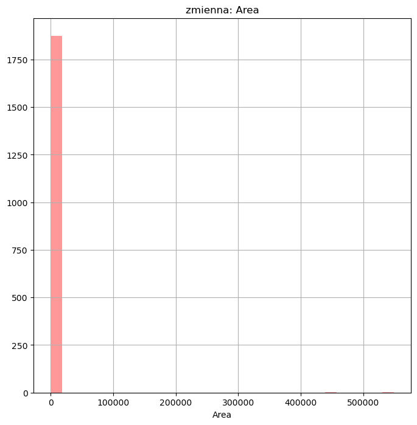

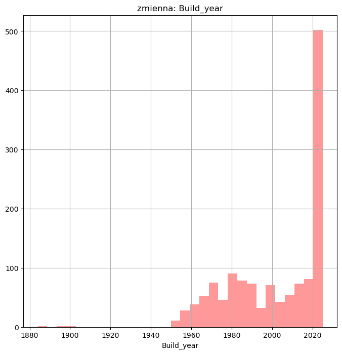

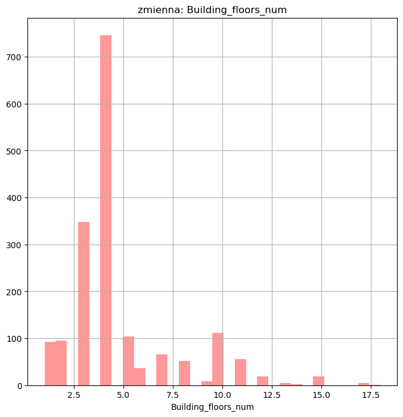

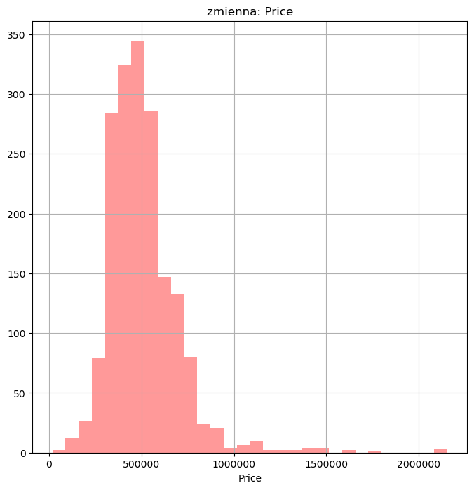

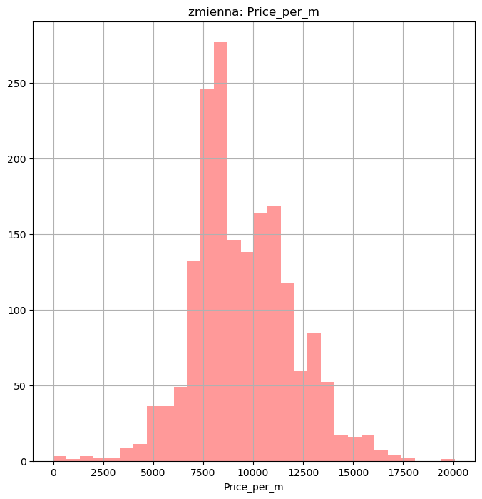

```python
for i in ['Area', 'Build_year', 'Building_floors_num', 'Price', 'Price_per_m']:
    plt.figure(figsize=(8,8))
    sns.distplot(df_without_duplicates[i], bins=30, kde=False, color='red')
    plt.ticklabel_format(style='plain', axis='x')
    plt.title(f'zmienna: {i}')
    plt.grid()
```

Zmienna dotycząca powierzchni charakteryzuje się obserwacjami odstającymi, które wydają się błędne - mieszkania o powierzchni 100 000 metrów kwadratowych trudno jest sobie wyobrazić

```python
display(df_without_duplicates[df_without_duplicates['Area'] > 100000][['Area', 'Price_per_m', 'Price', 'description']])
```

|  | Area | Price_per_m | Price | description |
| --- | --- | --- | --- | --- |
| 1024 | 549000.0 | 1.0 | 549000.0 | <p><strong>OFERTA DEVELOPERSKA:</strong><br/>W... |
| 1170 | 449000.0 | 1.0 | 449000.0 | <p><br/><strong>*** DZIEŃ OTWARTY, SOBOTA 3 LU... |
| 1793 | 450000.0 | 1.0 | 450000.0 | <p><br/><strong>* 2 ODDZIELNE POKOJE * OS. MIC... |

```python
df_without_duplicates['Area'] = [i if i < 100000 else i / 10000 for i in df_without_duplicates['Area'] ]
ads_id_to_change = ['64872752', '64774851', '65100261']
# cena za metr kwadratowy * 10000 - wartościach były '1'
df_without_duplicates['Price_per_m'] = [x * 10000 if y in ads_id_to_change else x for x, y in zip(df_without_duplicates['Price_per_m'], df_without_duplicates['id'])]
```

Ponowne zobrazowanie zmiennej powierzchni mieszkań pokazuje, że wartosci są już bliższe temu, co można obserwować w świecie rzeczywistym.  
Nadal występują wartości odstające - warto przyjrzeć się mieszkaniom powyzej 150 metrów kwadratowych.

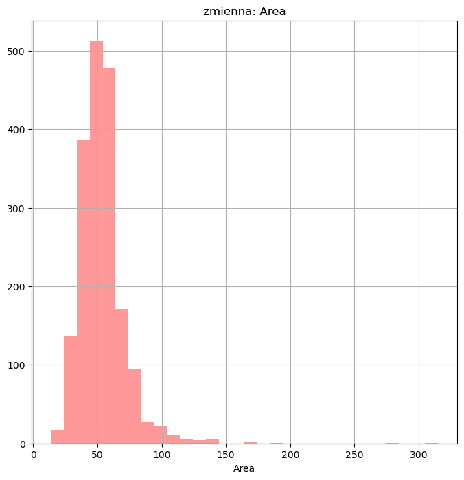

```python
plt.figure(figsize=(8,8))
sns.distplot(df_without_duplicates['Area'], bins=30, kde=False, color='red')
plt.ticklabel_format(style='plain', axis='x')
plt.title(f'zmienna: Area')
plt.grid()
```

```python
df_without_duplicates[df_without_duplicates['Area'] > 150]
```

|  | lang | id | relativeUrl | publicId | market | advertiserType | title | description | url | slug | createdAt | modifiedAt | features | MarketType | Area | Build_year | Building_floors_num | Country | City | City_id | Construction_status | Extras_types | Floor_no | ProperType | Province | Rooms_num | Security_types | Price | Price_per_m | … |
| --- | --- | --- | --- | --- | --- | --- | --- | --- | --- | --- | --- | --- | --- | --- | --- | --- | --- | --- | --- | --- | --- | --- | --- | --- | --- | --- | --- | --- | --- | --- |
| 1080 | pl | 64683210 | /pl/oferta/duzy-dwupoziomowy-apartament-dla-wy... | 4np3A | SECONDARY | business | Duży, dwupoziomowy apartament dla wymagających | <p>Na sprzedaż wyjątkowy, dwupoziomowy apartam... | https://www.otodom.pl/pl/oferta/duzy-dwupoziom... | duzy-dwupoziomowy-apartament-dla-wymagajacych-... | 2023-10-05 | 2024-02-02 | [monitoring / ochrona, garaż/miejsce parkingowe] | secondary | 169.0 | 2022.0 | 2.0 | Polska | bialystok | 204 | to_completion | garage | 0.0 | mieszkanie | podlaskie | 4.0 | monitoring | 1424000.0 | 8426.0 | … |
| 1176 | pl | 64771318 | /pl/oferta/zyj-i-pracuj-w-domu-pelnym-mozliwos... | 4nLYG | SECONDARY | business | Żyj i Pracuj w Domu Pełnym Możliwości? Sprawdź... | <p><strong>Dom z Możliwościami Działalności Go... | https://www.otodom.pl/pl/oferta/zyj-i-pracuj-w... | zyj-i-pracuj-w-domu-pelnym-mozliwosci-sprawdz-... | 2023-11-02 | 2024-01-31 | [meble, balkon, garaż/miejsce parkingowe, taras] | secondary | 315.0 | 1985.0 | 4.0 | Polska | bialystok | 204 | ready_to_use | balcony,garage,terrace | 4.0 | mieszkanie | podlaskie | 8.0 |  | 1499999.0 | 4762.0 | … |
| 1466 | pl | 62942670 | /pl/oferta/mieszkanie-280-m-bialystok-ID4g6gm | 4g6gm | PRIMARY | business | Mieszkanie, 280 m², Białystok | <p>****** KOMPLEKS MIESZKAŃ *******<br/>Zapras... | https://www.otodom.pl/pl/oferta/mieszkanie-280... | mieszkanie-280-m-bialystok-ID4g6gm | 2022-04-01 | 2024-01-21 | [] | primary | 280.0 | 2017.0 | 2.0 | Polska | bialystok | 204 | to_completion |  | 1.0 | mieszkanie | podlaskie | 3.0 |  | 1500000.0 | 5357.0 | … |
| 1644 | pl | 51760556 | /pl/oferta/bezposrednio-szeregowka-bialystok-I... | 3wbhG | PRIMARY | private | Bezpośrednio szeregówka Białystok | <p></p>\r\n<p>Sprzedam budynek mieszkalny w za... | https://www.otodom.pl/pl/oferta/bezposrednio-s... | bezposrednio-szeregowka-bialystok-ID3wbhG | 2017-12-23 | 2024-02-24 | [garaż/miejsce parkingowe, ogródek] | primary | 188.0 | 2023.0 | 2.0 | Polska | bialystok | 204 | to_completion | garage,garden | NaN | mieszkanie | podlaskie | 6.0 |  | 699000.0 | 3718.0 | … |
| 1833 | pl | 64668446 | /pl/oferta/apartament-136-m2-33-m2-garaz-ID4nlds | 4nlds | PRIMARY | private | Apartament 136 m2+33 m2 Garaż | <p>Na sprzedaż apartament 2 poziomowy o powi... | https://www.otodom.pl/pl/oferta/apartament-136... | apartament-136-m2-33-m2-garaz-ID4nlds | 2023-10-02 | 2024-02-08 | [internet, system alarmowy, teren zamknięty, d... | primary | 169.0 | 2022.0 | 2.0 | Polska | bialystok | 204 | to_completion | garage,garden,terrace,two_storey,usable_room | 0.0 | mieszkanie | podlaskie | 5.0 | alarm,closed_area,entryphone,monitoring | 1424000.0 | 8426.0 | … |

Mieszkania o powierzchni powyżej 150 metrów wyglądają na poprawnie dodane. Z opisu ogłoszeń wynika, że są to albo bardzo duże apartamenty lub szeregówki skategoryzowane przez serwis Oto Dom jako mieszkania. Powinny zostać w analizowanym zbiorze danych bez dalszych ingerencji.

Warto zwrócić uwagę na zmienne dotyczącej ceny za mieszkanie: ceny za całość oraz ceny za metr kwadratowy.  
W przypadku zmiennej ceny całkowitej na histogramie widać wartości zbliżające się do zera, co wydaje się nienaturalnym zjawiskiem. Podobnie w przypadku ceny za metr kwadratowy (wcześniejsze kroki analizy pokazały, że w wyniku błędu w dodawaniu ogloszenia bądź niechęci ogłoszeniodawcy do dodawania takich danych w polu o cenie za metr kwadratowy znajdują się wartości '1' - to zjawisko należy zweryfikować).

Analizując dalej zmienne numeryczne warto zwrócić uwagę na rozkład kwantyli oraz na wartości minimalne /maksymalne zmiennych - dalsza analiza wartości odstających.

- mieszkanie o powierzchni 14 metrów kwadratowych
- ogłoszenie z ceną za mieszkanie 17 K (cena za matr kwadratowy 714 zł)
- w przypadku liczby pięter budynków, oraz piętra, na którym znajduje się sprzedawane mieszkanie nie budzi żadnych wątpliwości
- podobnie rok powstania budynku. Białystok to miasto zniszczone w dużej mierze w trakcie działań wojennych z okresu II Wojny Światowej wiec nie zaskakuje budownictwo z drugiej połowy XX wieku i późniejsze. Natomiast ogłoszenia dotyczące starszych budowli znajdują się w historycznych dzielnicach miasta, które przetrwały okres II Wojny Światowej. Nie jest ich też dużo - 3 budowle wybudowane przed 1950 rokiem

```python
df_without_duplicates['price_k_pln'] = df_without_duplicates["Price"]/1000.0
df_without_duplicates[['Area', 'price_k_pln', 'Price_per_m', 'Building_floors_num','Floor_no', 'Build_year']].describe().round()
```

|  | Area | price_k_pln | Price_per_m | Building_floors_num | Floor_no | Build_year |
| --- | --- | --- | --- | --- | --- | --- |
| count | 1877.0 | 1803.0 | 1803.0 | 1762.0 | 1840.0 | 1350.0 |
| mean | 54.0 | 507.0 | 9509.0 | 5.0 | 3.0 | 2002.0 |
| std | 19.0 | 194.0 | 2425.0 | 3.0 | 2.0 | 23.0 |
| min | 14.0 | 17.0 | 714.0 | 1.0 | -1.0 | 1884.0 |
| 25% | 43.0 | 388.0 | 7904.0 | 3.0 | 1.0 | 1981.0 |
| 50% | 51.0 | 472.0 | 9150.0 | 4.0 | 2.0 | 2010.0 |
| 75% | 61.0 | 584.0 | 11021.0 | 5.0 | 3.0 | 2023.0 |
| max | 315.0 | 2155.0 | 20090.0 | 18.0 | 11.0 | 2025.0 |

```python
df_without_duplicates[df_without_duplicates['Price'] < 18000]
```

|  | lang | id | relativeUrl | publicId | market | advertiserType | title | description | url | slug | createdAt | modifiedAt | features | MarketType | Area | Build_year | Building_floors_num | Country | City | City_id | Construction_status | Extras_types | Floor_no | ProperType | Province | Rooms_num | Security_types | Price | Price_per_m | … |
| --- | --- | --- | --- | --- | --- | --- | --- | --- | --- | --- | --- | --- | --- | --- | --- | --- | --- | --- | --- | --- | --- | --- | --- | --- | --- | --- | --- | --- | --- | --- |
| 660 | pl | 64976231 | /pl/oferta/udzial-w-wysokosci-1-3-w-lokalu-mie... | 4oDhJ | SECONDARY | private | Udział w wysokości 1/3 w lokalu mieszkalnym | <p> <em> </em></p>\r\n<p> <em> <strong>WAR... | https://www.otodom.pl/pl/oferta/udzial-w-wysok... | udzial-w-wysokosci-1-3-w-lokalu-mieszkalnym-ID... | 2024-01-10 | 2024-01-15 | [] | secondary | 23.85 | NaN | NaN | Polska | bielsk-podlaski | 1242 |  |  | NaN | mieszkanie | podlaskie | 1.0 |  | 17018.0 | 714.0 | … |

### 2.5 Przygotowanie dodatkowych zmiennych

Powrót do początku

W zbiorze danych występują zmienne kategoryczne, które należałoby przekształcić na zmienne 0-1 przed poddaniem ich dalszej analizie.

**Zakodowanie zmiennych kategorycznych:**

```python
dummy_construction_status = pd.get_dummies(df_without_duplicates['Construction_status'], prefix='construction').drop('construction_', axis=1)
df_without_duplicates = pd.concat([df_without_duplicates, dummy_construction_status], axis=1)
dummy_advertiserType = pd.get_dummies(df_without_duplicates['advertiserType'], prefix='advertiser')
df_without_duplicates = pd.concat([df_without_duplicates, dummy_advertiserType], axis=1)
dummy_MerketType = pd.get_dummies(df_without_duplicates['MarketType'], prefix='MerketType')
df_without_duplicates = pd.concat([df_without_duplicates, dummy_MerketType], axis=1)
dummy_district = pd.get_dummies(df_without_duplicates['district_name'], prefix='district')
df_without_duplicates = pd.concat([df_without_duplicates, dummy_district], axis=1)
```

```python
df_without_duplicates['if_bialystok'] = [1 if x == 'bialystok' else 0 for x in df_without_duplicates['City']]
```

## 3. Analiza ogłoszeń sprzedaży mieszkań w Białymstoku

Powrót do początku

### 3.1 Charakterystyka ogłoszeń ze względu na zmienne numeryczne

Powrót do początku

Ogólna charakterystyka badanych ofert sprzedaży mieszkań ze względu na cenę za metr kwadratowy, powierzchnię mieszkania, rok powstania budynku oraz wysokość budynku, w którym znajduje się mieszkanie na sprzedaż.

```python
num_var_to_compare = ['Area', 'Build_year', 'Building_floors_num', 'Floor_no', 'Rooms_num', 'Price_per_m', 'n_features']

count_groups = (
    df_without_duplicates[num_var_to_compare]
    .describe()
    .round()
    .fillna(-1)
    .astype('int')
    .reset_index()

)
display(count_groups)
```

|  | index | Area | Build_year | Building_floors_num | Floor_no | Rooms_num | Price_per_m | n_features |
| --- | --- | --- | --- | --- | --- | --- | --- | --- |
| 0 | count | 1877 | 1350 | 1762 | 1840 | 1877 | 1803 | 1877 |
| 1 | mean | 54 | 2002 | 5 | 3 | 3 | 9509 | 6 |
| 2 | std | 19 | 23 | 3 | 2 | 1 | 2425 | 4 |
| 3 | min | 14 | 1884 | 1 | -1 | 0 | 714 | 0 |
| 4 | 25% | 43 | 1981 | 3 | 1 | 2 | 7904 | 3 |
| 5 | 50% | 51 | 2010 | 4 | 2 | 3 | 9150 | 5 |
| 6 | 75% | 61 | 2023 | 5 | 3 | 3 | 11021 | 9 |
| 7 | max | 315 | 2025 | 18 | 11 | 8 | 20090 | 22 |

### 3.2 Charakterystyka przeciętnej ceny mieszkania ze względu na zmienne kategoryczne

Powrót do początku

W poniższej części zostanie przeanalizowany związek ceny mieszkania (cena za metr kwadratowy) w zależności od zmiennych kategorycznych tj. typ rynku (mieszkanie z rynku pierwotnego czy wtórnego), status ogłoszeniodawcy (ogłoszenie sprzedaży mieszkania wystawione przez firmę - biznes, czy przez osobę prywatną), status nieruchomości (gotowe do wprowadzenia, do remontu lub do generalnego remontu) oraz miejsce, w którym znajduje się dane mieszkanie (miejscowość jeżeli wystawione mieszkanie jest spoza granic Białegostoku) lub dzielnica miasta.

```python
cat_var_to_explore = ['MarketType', 'advertiserType',  'Construction_status', 'City', 'district_name']
```

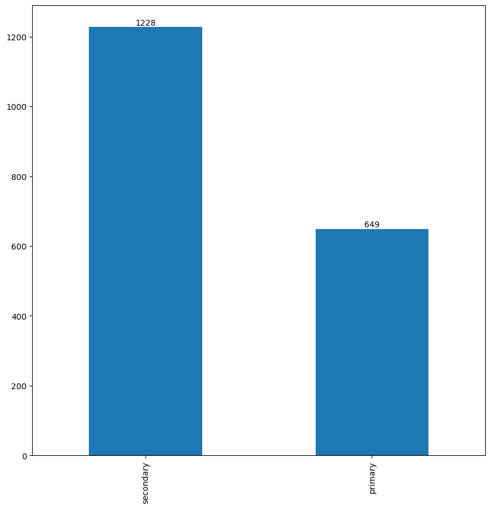

|  | MarketType | n_ads | mean_price_m2 | mean_area | mean_year | mean_build_floor_num | mean_n_features | perc_share |
| --- | --- | --- | --- | --- | --- | --- | --- | --- |
| 0 | secondary | 1228 | 9662 | 54 | 1994 | 5 | 6 | 0.65 |
| 1 | primary | 649 | 9183 | 55 | 2023 | 4 | 6 | 0.35 |

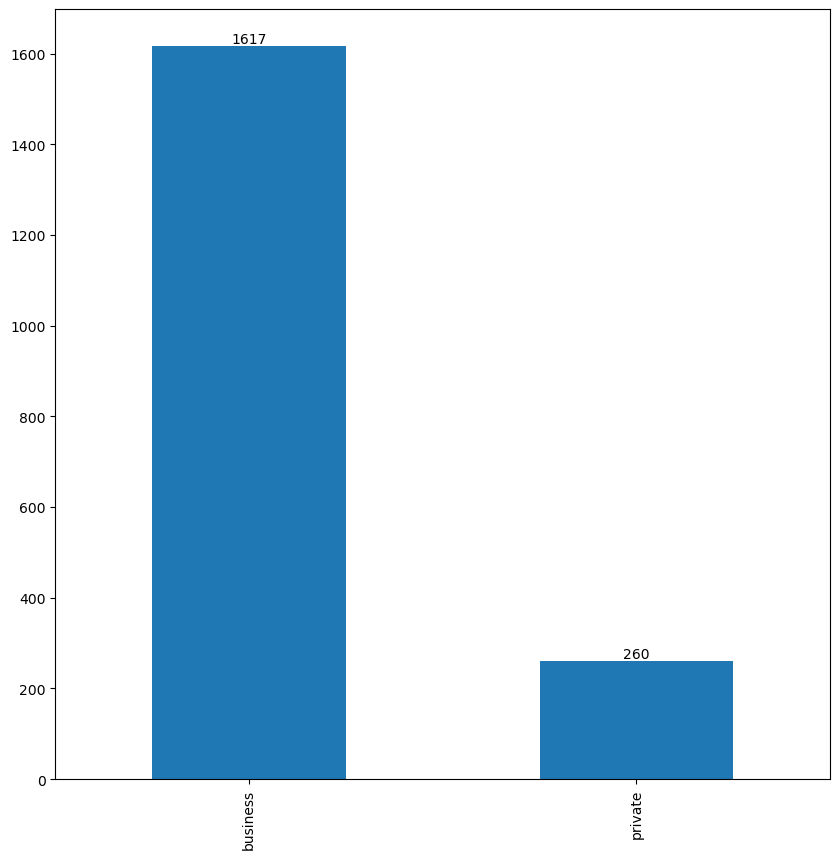

|  | advertiserType | n_ads | mean_price_m2 | mean_area | mean_year | mean_build_floor_num | mean_n_features | perc_share |
| --- | --- | --- | --- | --- | --- | --- | --- | --- |
| 0 | business | 1617 | 9366 | 54 | 2001 | 5 | 5 | 0.86 |
| 1 | private | 260 | 10358 | 53 | 2002 | 5 | 9 | 0.14 |

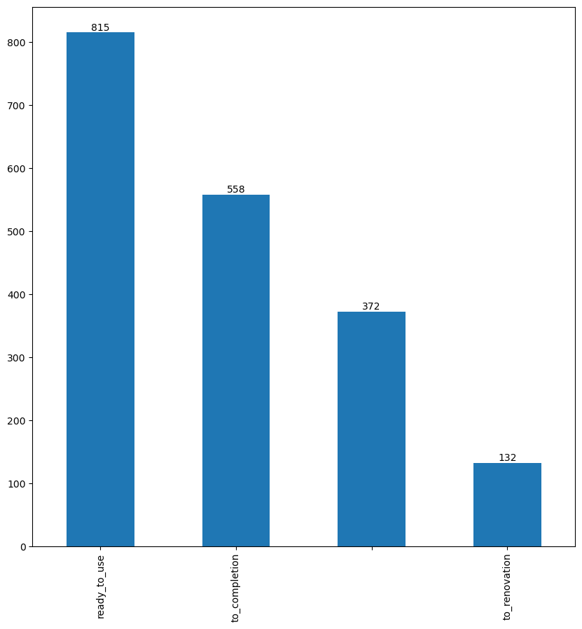

|  | Construction_status | n_ads | mean_price_m2 | mean_area | mean_year | mean_build_floor_num | mean_n_features | perc_share |
| --- | --- | --- | --- | --- | --- | --- | --- | --- |
| 0 | ready_to_use | 815 | 10414 | 54 | 1999 | 5 | 7 | 0.43 |
| 1 | to_completion | 558 | 8784 | 55 | 2018 | 4 | 6 | 0.30 |
| 2 |  | 372 | 9252 | 54 | 2001 | 5 | 3 | 0.20 |
| 3 | to_renovation | 132 | 7308 | 51 | 1977 | 5 | 4 | 0.07 |

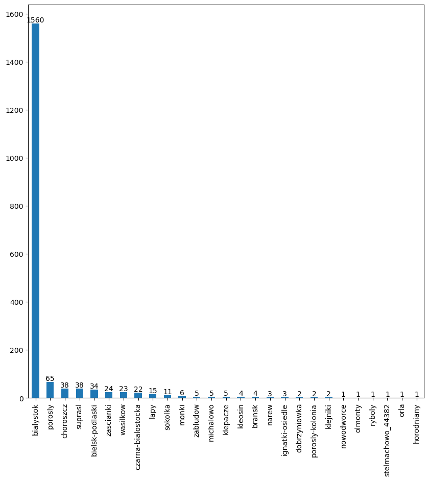

|  | City | n_ads | mean_price_m2 | mean_area | mean_year | mean_build_floor_num | mean_n_features | perc_share |
| --- | --- | --- | --- | --- | --- | --- | --- | --- |
| 0 | bialystok | 1560 | 9984 | 54 | 2001 | 5 | 6 | 0.83 |
| 1 | porosly | 65 | 7978 | 57 | 2025 | 3 | 5 | 0.03 |
| 2 | suprasl | 38 | 6442 | 47 | -1 | 1 | 7 | 0.02 |
| 3 | choroszcz | 38 | 7166 | 58 | 2000 | 4 | 5 | 0.02 |
| 4 | bielsk-podlaski | 34 | 5781 | 51 | 1988 | 4 | 4 | 0.02 |
| 5 | zascianki | 24 | 8567 | 63 | 2024 | 3 | 3 | 0.01 |
| 6 | wasilkow | 23 | 9133 | 55 | 2009 | 3 | 5 | 0.01 |
| 7 | czarna-bialostocka | 22 | 5369 | 49 | 1981 | 3 | 4 | 0.01 |
| 8 | lapy | 15 | 5537 | 45 | 1982 | 3 | 3 | 0.01 |
| 9 | sokolka | 11 | 6307 | 50 | 1977 | 4 | 2 | 0.01 |
| 10 | monki | 6 | 5104 | 65 | 1998 | 3 | 6 | 0.00 |
| 11 | klepacze | 5 | 5175 | 88 | 2024 | 1 | 2 | 0.00 |
| 12 | michalowo | 5 | 5057 | 50 | 1980 | 3 | 4 | 0.00 |
| 13 | zabludow | 5 | 3593 | 70 | 2012 | 3 | 5 | 0.00 |
| 14 | kleosin | 4 | 8460 | 51 | 2006 | 3 | 6 | 0.00 |
| 15 | bransk | 4 | 5682 | 41 | 1973 | 2 | 8 | 0.00 |
| 16 | narew | 3 | 4741 | 49 | 1970 | 2 | 5 | 0.00 |
| 17 | ignatki-osiedle | 3 | 8997 | 53 | 2006 | 3 | 7 | 0.00 |
| 18 | klejniki | 2 | 3696 | 37 | 1970 | 1 | 8 | 0.00 |
| 19 | dobrzyniowka | 2 | 2792 | 79 | 1985 | 2 | 2 | 0.00 |
| 20 | porosly-kolonia | 2 | 7470 | 56 | 2024 | 1 | 0 | 0.00 |
| 21 | stelmachowo_44382 | 1 | 4129 | 73 | 1985 | 2 | 6 | 0.00 |
| 22 | horodniany | 1 | 12500 | 69 | 2021 | 3 | 18 | 0.00 |
| 23 | ryboly | 1 | 3482 | 36 | -1 | 2 | 1 | 0.00 |
| 24 | orla | 1 | 3367 | 49 | -1 | 2 | 2 | 0.00 |
| 25 | nowodworce | 1 | 7609 | 46 | 2023 | 3 | 11 | 0.00 |
| 26 | olmonty | 1 | 5502 | 85 | 2024 | 1 | 6 | 0.00 |

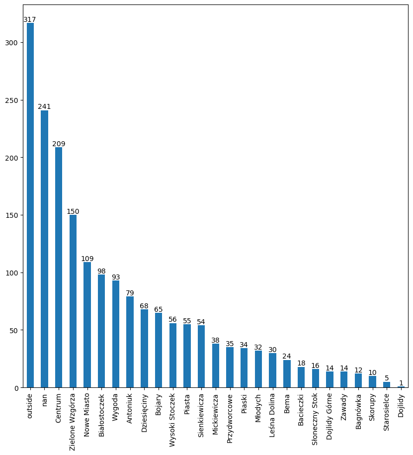

|  | district_name | n_ads | mean_price_m2 | mean_area | mean_year | mean_build_floor_num | mean_n_features | perc_share |
| --- | --- | --- | --- | --- | --- | --- | --- | --- |
| 0 | outside | 317 | 6934 | 55 | 2007 | 3 | 5 | 0.17 |
| 1 | nan | 241 | 10155 | 52 | 1999 | 5 | 5 | 0.13 |
| 2 | Centrum | 209 | 11177 | 49 | 1997 | 6 | 5 | 0.11 |
| 3 | Zielone Wzgórza | 150 | 8115 | 52 | 1993 | 4 | 10 | 0.08 |
| 4 | Nowe Miasto | 109 | 9872 | 63 | 2004 | 5 | 7 | 0.06 |
| 5 | Białostoczek | 98 | 11389 | 54 | 2012 | 7 | 6 | 0.05 |
| 6 | Wygoda | 93 | 9452 | 58 | 2018 | 3 | 3 | 0.05 |
| 7 | Antoniuk | 79 | 9909 | 48 | 1994 | 6 | 5 | 0.04 |
| 8 | Dziesięciny | 68 | 8972 | 50 | 1990 | 6 | 6 | 0.04 |
| 9 | Bojary | 65 | 10993 | 56 | 2002 | 6 | 7 | 0.03 |
| 10 | Wysoki Stoczek | 56 | 9658 | 58 | 2002 | 6 | 7 | 0.03 |
| 11 | Piasta | 55 | 9653 | 54 | 1992 | 6 | 6 | 0.03 |
| 12 | Sienkiewicza | 54 | 10688 | 49 | 1993 | 6 | 6 | 0.03 |
| 13 | Mickiewicza | 38 | 9751 | 62 | 1982 | 4 | 6 | 0.02 |
| 14 | Przydworcowe | 35 | 12057 | 60 | 2005 | 5 | 7 | 0.02 |
| 15 | Piaski | 34 | 10761 | 51 | 1989 | 8 | 6 | 0.02 |
| 16 | Młodych | 32 | 9759 | 50 | 1987 | 4 | 5 | 0.02 |
| 17 | Leśna Dolina | 30 | 8992 | 55 | 1997 | 4 | 6 | 0.02 |
| 18 | Bema | 24 | 9849 | 52 | 1996 | 5 | 5 | 0.01 |
| 19 | Bacieczki | 18 | 9519 | 51 | 2004 | 3 | 8 | 0.01 |
| 20 | Słoneczny Stok | 16 | 8687 | 55 | 1989 | 6 | 6 | 0.01 |
| 21 | Dojlidy Górne | 14 | 7373 | 79 | 2023 | 1 | 6 | 0.01 |
| 22 | Zawady | 14 | 9846 | 68 | 2023 | 2 | 5 | 0.01 |
| 23 | Bagnówka | 12 | 9615 | 63 | 2015 | 1 | 7 | 0.01 |
| 24 | Skorupy | 10 | 9153 | 64 | 2019 | 2 | 5 | 0.01 |
| 25 | Starosielce | 5 | 7908 | 52 | 1995 | 6 | 3 | 0.00 |
| 26 | Dojlidy | 1 | 13560 | 78 | 2021 | 2 | 15 | 0.00 |

```python
for i in cat_var_to_explore:
    ax = (
        df_without_duplicates[i]
        .value_counts()
        .sort_values(ascending=False)
        .plot(kind='bar', figsize=(10,10), grid=False)
    )
    ax.bar_label(ax.containers[0])
    plt.show()

    sum_df = (
        df_without_duplicates
        .groupby(i)
        .agg(
            n_ads= ('id', 'size'),
            mean_price_m2= ('Price_per_m', 'mean'),
            mean_area = ('Area', 'mean'),
            mean_year = ('Build_year', 'mean'),
            mean_build_floor_num = ('Building_floors_num', 'mean'),
            mean_n_features = ('n_features', 'mean')
        )
        .round()
        .fillna(-1)
        .astype('int')
        .sort_values(ascending=False, by ='n_ads')
        .reset_index()
    )
    sum_df['perc_share'] = round(sum_df['n_ads'] / df_without_duplicates.shape[0], 2)
    display(sum_df)
```

#### 3.2.1 Typ rynku - rynek pierwotny vs. rynek wtórny

Powrót do początku

- najwięcej mieszkań na sprzedaż pochodzi z rynku wtórnego
- cena mieszkań za metr kwadratowy z rynku wtórnego jest przeciętnie wyższa o około 500 zł za metr kwadratowy
- brak znaczącej różnicy pomiędzy rynkiem pierwotnym, a wtórnym jeżeli chodzi o przeciętną powierzchnię sprzedawanego mieszkania. Jest to 54-55 metrów kwadratowych
- naturalnie - mieszkania z rynku wtórnego są starsze. Przeciętny wiek wystawionego mieszkania z rynku wtórnego to około 30 lat (budynek wybudowany w roku 1994)

#### 3.2.2 Status ogłoszeniodawcy - typ podmiotu wystawiającego ogłoszenie (firma vs. osoba prywatna)

Powrót do początku

#### 3.2.3 Status mieszkania

Powrót do początku

#### 3.2.4 Miejscowość

Powrót do początku

##### 3.2.4.1 Liczba ogłoszeń

Powrót do początku

##### 3.2.4.2 Cena

Powrót do początku

- Przeciętnie najdroższe są mieszkania położone w granicach admistracyjnych miasta Białystok - prawie 10 000 zł za metr kwadratowy
- szukając mieszkania do zakupu - można zwrócić uwagę na bloki znajdujące się poza Białymstokiem w których mieszkania są znacznie tańsze. W Porosłach przeciętna cena za metr kwadratowy jest 2 tysiące złotych niższa. W Supraślu i Choroszczy - które są bardziej oddalone - potencjalny nabywca przeciętnie zapłaci mniej o 3-3.5 tysiąca złotych mniej, niż za podobne mieszkanie w Białymstoku.
- Można zauważyć, że im dana miejscowość leży bliżej miasta Białystok - cena za metr kwadratowy wzrasta (np. w Wasilkowie, miejscowość którą można uznać już za jedną z dzielnic miasta - przeciętna cena za metr kwadratowy jest niższa o tysiąc złotcyh niż w samym Białymstoku)

##### 3.2.4.3 Powierzchnia oraz rok budowy

Powrót do początku

- pod względem przeciętnej powierzchni oferowanych mieszkań na sprzedaż poszczególne miejscowości nie różnią się w znaczący sposó od siebie - szczególnie Białystok i mieszkania na sprzedaż w miejscowościach graniczących, bądź leżących niedaleko Białegostoku (około 55 metrów kwadratowych)
- przeciętnie nieco większe mieszkania na sprzedaż znajdują się w Choroszczy (58 metrów kwadratowych) oraz w Zaściankach (63 metry kwadratowe)
- natomiast największe mieszkania można znaleźć w miejscowościach w któych dominuje zabudowa domów jednorodzinnych. Można stąd wnioskować, że są to oferty szeregówek (które charakteryzują się większą powierzchnią niż mieszkania w blokach, ale przez serwis Oto Dom bądź ogłoszeniodawców są kategoryzowane jako mieszkania)
- sam Białystok charakteryzuje się stosunkowo młodymi mieszkaniami na sprzedaż (wiek przeciętnego mieszkania na sprzedaż to 23 lata)
- Porosły, Zaścianki, Klepacze - to miejscowości, w których budownictwo mieszkalne dopiero zaczyna powstawać. Wiek przeciętnego mieszkania na sprzedaż to 1 rok (tzw. nowe budownictwo)
- bloki poza Białymstokiem charakteryzują się także niższą liczbą pięter. Przeciętna wysokość budynku w samym Białymstoku to 5 pięter, natomaist poza miastem takie budynki już nie występują

#### 3.2.5 Dzielnica miasta

Powrót do początku

##### 3.2.5.1 Liczba ogłoszeń

Powrót do początku

- warto jeszcze zwrócić uwagę na dzielnicę miasta, w której znajduje się sprzedawane mieszkanie. Kategorią "outside" zostały oznaczone mieszkania znajdujące się poza Białymstokiem
- dużą grupę ogłoszeń stanowią te, w których ogłoszeniodawca nie podał nazwy dzielnicy w której znajduje się oferowane mieszkanie na sprzedaż (13% wszystkich ogłoszeń).
- procentowo najwięcej mieszkań na sprzedaż znajduje się poza miastem i są one najtańsze
- pod kątem liczby mieszkań na sprzedaż najbardziej popularne dzielnice to: Centrum, Zielone Wzgórza, Nowe Miasto, Białostoczek, Wygoda, Antoniuk, Dziesięciny. Są to dzielnice w których dominuje zabudowa mieszkaniowa (bloki)
- podobne dzielnice to: Wysoki Stoczek, Piata, Piaski, Sienkiwicza, Mickiewicza, Przydworcowe

##### 3.2.5.2 Cena

Powrót do początku

- najtańsze mieszkania można znaleźć poza granicami miasta. Natomiast najdroższe dzielnic to: Przydworcowe (około 12K za metr kwadratowy), Białostoczek, Centrum (przeciętnie około 11 K za metr kwadratowy)
- osiedle Przydworcowe może charakteryzować się wyższą niż przeciętna ceną za metr kwadratowy z względu na swoje położenie - bliksość dworca oraz węzłów komunikacyjnych takich jak dworzec PKS oraz centrum przesiadkowe BKM (Białostockiej Komunikacji Miejskiej)
- Dojlidy - 13.5 K zł za metr kwadratowy, jednakże jest to osiedle domków jednorodzinnych. Warto zwrócić uwagę na stosunkowo dużą powierzchnię mieszkań. Są to oferty domów szeregowych (które przez sewris Otodom są traktowane jako mieszkania). Dodatkowo Dojlidy Górne charakteryzują się bardziej prestiżową zabudową, niż pozostałe regiony miasta
- Osiedla takie jak Bojary, Piaski, Sienkiewicza - charakteryzują się przeciętną ceną około 10 K za metr kwadratowy. Są to osiedla położone bardzo blisko centrum miasta.
- poniżej 10 tysięcy zł za metr kwadratowy można zapłacić na osiedlach takich jak: Antoniuk, Nowe Miasto, Bema, Zawady, Młodych, Mickiewicza, Wysoki Stoczek, Piasta, Dziesięciny, Zielone Wzgórza. Są to osiedla nieco oddalone o centrum miasta (z wyjątkiem Mickiewicz, Bema i Piasta) - ale w przypadku tych osiedli są to mieszkania w zabudowie zdecydowanie starszej i są to prawdopodobnie mieszkania przynajmniej do remontu lub do renowacji - które to charakteryzują się przeciętnie niższą ceną za metr kwadratowy. Potencjalny nabywca jednak musi mieć na uwadze dodatkowe koszta związane z odświeżeniam, bądź wyremontowaniem mieszkania.
- Dojlidy Górne charakteryzują sie stosunkowo nową zabudową, przeciętnie niższą ceną oraz przeciętnie wiekszą powierzchnią oferowanych mieszkań na sprzedaż. Dzielnica ta jest miejscem głównie o zabudowie złożonej z domów. Wniosek stąd, że są to głównie oferty mieszkań szeregówkach i to niedawno wybudowanych (przeciętny wiek oferowanego mieszkania to 1 rok). Może to być ciekawe rozwiązanie dla osób, które są zainteresowane mieszkaniem dalej od centrum miasta (na uboczu i z gorszą komunikacją miejską), ale zyskują tym większą powierzchnię oraz niższą niż przeciętna cena za metr kwadratowy.

### 3.3 Analiza przeciętnej ceny metra kwadratowego ze względu na położenie oraz typ mieszkania

Powrót do początku

W poniższej części przeciętna cena metra kwadratowego oferowanego mieszkania na sprzedaż zostanie porównana z typem danego mieszkania (status rynku - pierwotny vs. wtórny), typem ogłoszeniodawcy (osoba prywatna vs. firma), statusem mieszkania (gotowe do wprowadzenia, do odświeżenia lub do remontu) i z położeniem. W poprzedniej części zauważono, że znaczący wpływ na przeciętną cenę metra kwadratowego sprzedawanego mieszkania ma miejsce, w którym dane mieszkanie się znajduje. Pozostałe zmienne zostaną porównane do tej kategorii (zmienna if_bialystok, 1 - oznacza, że oferowane mieszkanie na sprzedaż znajduje się w granicach administracyjnych miasta, 0 - poza granicami). Procentowy udział liczby ofert (perc_share) w tym przypadku jest wyliczany w ramach grupy if_bialystok (liczba ofert sprzedaży mieszkań znajdujących się w samym Białymstoku lub poza miastem).

```python
if_bialystok_df = (
    df_without_duplicates
    .groupby(['if_bialystok'])
    .agg(
        n_ads= ('id', 'size'),
        mean_price_m2= ('Price_per_m', 'mean'),
        mean_area = ('Area', 'mean'),
        mean_year = ('Build_year', 'mean'),
        mean_build_flor_no = ('Building_floors_num', 'mean'),
        mean_flor_no = ('Floor_no', 'mean'),
        mean_features = ('n_features', 'mean')
    )
    .round()
    .fillna(-1)
    .astype('int')
    .sort_values(by=['if_bialystok', 'n_ads'], ascending=False)
    .reset_index()
)

display(if_bialystok_df)
```

|  | if_bialystok | n_ads | mean_price_m2 | mean_area | mean_year | mean_build_flor_no | mean_flor_no | mean_features |
| --- | --- | --- | --- | --- | --- | --- | --- | --- |
| 0 | 1 | 1560 | 9984 | 54 | 2001 | 5 | 3 | 6 |
| 1 | 0 | 317 | 6934 | 55 | 2007 | 3 | 1 | 5 |

Wśród badanych ofert sprzedaży najwięcej mieszkań znajduje się w granicach miasta (83% wszystkich mieszkań). Przeciętna cena za metr kwadratowy jest wyższa o prawie 3 tysiące złotych wśród mieszkań znajdujących się w granicach miasta. Przeciętna dostępna przestrzeń oferowanych mieszkań nie różni się ze względu na położenie mieszknia. Natomiast bloki, w których znajdują się oferowane mieszkania na sprzedaż są nieco wyższe w Białymstoku niż poza miastem. Podobnie - szukając mieszkania w mieście z większym prawdopodobieństwem znajdziemy mieszkanie na wyższym piętrze (przeciętnie na 3) niż poza granicami miasta.

```python
check_diff_cat = ['MarketType', 'advertiserType', 'Construction_status']

for i in check_diff_cat:
    check_df = (
        df_without_duplicates
        .groupby([i, 'if_bialystok'])
        .agg(
            n_ads= ('id', 'size'),
            mean_price_m2= ('Price_per_m', 'mean'),
            mean_area = ('Area', 'mean'),
            mean_year = ('Build_year', 'mean'))
        .round()
        .fillna(-1)
        .astype('int')
        .sort_values(by=['if_bialystok', 'n_ads'], ascending=False)
        .reset_index()
    )

    check_df['perc_share'] = check_df['n_ads'] / check_df.groupby('if_bialystok')['n_ads'].transform('sum')
    display(check_df)
```

|  | MarketType | if_bialystok | n_ads | mean_price_m2 | mean_area | mean_year | perc_share |
| --- | --- | --- | --- | --- | --- | --- | --- |
| 0 | secondary | 1 | 1075 | 10119 | 54 | 1994 | 0.689103 |
| 1 | primary | 1 | 485 | 9659 | 55 | 2023 | 0.310897 |
| 2 | primary | 0 | 164 | 7520 | 56 | 2024 | 0.517350 |
| 3 | secondary | 0 | 153 | 6445 | 53 | 1992 | 0.482650 |

|  | advertiserType | if_bialystok | n_ads | mean_price_m2 | mean_area | mean_year | perc_share |
| --- | --- | --- | --- | --- | --- | --- | --- |
| 0 | business | 1 | 1333 | 9818 | 54 | 2000 | 0.854487 |
| 1 | private | 1 | 227 | 10933 | 52 | 2002 | 0.145513 |
| 2 | business | 0 | 284 | 7006 | 55 | 2007 | 0.895899 |
| 3 | private | 0 | 33 | 6396 | 55 | 2004 | 0.104101 |

|  | Construction_status | if_bialystok | n_ads | mean_price_m2 | mean_area | mean_year | perc_share |
| --- | --- | --- | --- | --- | --- | --- | --- |
| 0 | ready_to_use | 1 | 732 | 10816 | 54 | 1999 | 0.469231 |
| 1 | to_completion | 1 | 393 | 9191 | 55 | 2016 | 0.251923 |
| 2 |  | 1 | 335 | 9573 | 53 | 2002 | 0.214744 |
| 3 | to_renovation | 1 | 100 | 8095 | 51 | 1976 | 0.064103 |
| 4 | to_completion | 0 | 165 | 7658 | 55 | 2022 | 0.520505 |
| 5 | ready_to_use | 0 | 83 | 6866 | 55 | 1996 | 0.261830 |
| 6 |  | 0 | 37 | 6365 | 56 | 2000 | 0.116719 |
| 7 | to_renovation | 0 | 32 | 4850 | 52 | 1978 | 0.100946 |

#### 3.3.1 Typ rynku, typ ogłoszeniodawcy, typ mieszkania

Powrót do początku

#### 3.3.2 Typ rynku vs. typ ogłoszeniodawcy i status mieszkania ze wzglęu na położenie

Powrót do początku

Dodatkowo warto również zwrócić uwagę na prawdopodobnie istniejące współkoleracje między poszczególnymi zmiennymi - typ rynku ze względu na typ ogłoszeniodawcy oraz położenie sprzedawanego mieszkania (w mieście czy poza nim).

```python
check_df = (
    df_without_duplicates
    .groupby(['MarketType', 'advertiserType', 'if_bialystok'])
    .agg(n_ads= ('id', 'size'), mean_price_m2= ('Price_per_m', 'mean'))
    .round()
    .fillna(-1)
    .astype('int')
    .sort_values(by=['if_bialystok', 'n_ads'], ascending=False)
    .reset_index()
)

check_df['perc_share'] = check_df['n_ads'] / check_df.groupby('if_bialystok')['n_ads'].transform('sum')
display(check_df)
```

|  | MarketType | advertiserType | if_bialystok | n_ads | mean_price_m2 | perc_share |
| --- | --- | --- | --- | --- | --- | --- |
| 0 | secondary | business | 1 | 888 | 9962 | 0.569231 |
| 1 | primary | business | 1 | 445 | 9502 | 0.285256 |
| 2 | secondary | private | 1 | 187 | 10865 | 0.119872 |
| 3 | primary | private | 1 | 40 | 11251 | 0.025641 |
| 4 | primary | business | 0 | 155 | 7589 | 0.488959 |
| 5 | secondary | business | 0 | 129 | 6469 | 0.406940 |
| 6 | secondary | private | 0 | 24 | 6315 | 0.075710 |
| 7 | primary | private | 0 | 9 | 6612 | 0.028391 |

Zestawiając przeciętną cenę metra kwadratowgo w badanych ogłoszeniach mieszkań na sprzedaż z typem rynku oraz typem ogłoszeniodawcy nie obserwuje się znaczących różnić w porównaniu do analizowania zmiennych oddzielnie. W Białymstoku mieszkania wystawione przez firmy charakteryzują się niższą ceną, niż te wystawiane przez osoby prywatne (bez względu na typ rynku). Jednak mieszkania znajdujące się poza miastem, a które zostały wystawione na sprzedaż przez firmy są droższe. Warto też zwrócić uwagę na mieszkania wystawione prywatnie z rynku wtórnego, a znjadujące się poza miastem - te charakteryzują się najniższą przeciętną ceną za metr kwadratowy.

```python
check_df = (
    df_without_duplicates
    .groupby(['MarketType', 'Construction_status', 'if_bialystok'])
    .agg(n_ads= ('id', 'size'), mean_price_m2= ('Price_per_m', 'mean'), mean_area = ('Area', 'mean'))
    .round()
    .fillna(-1)
    .astype('int')
    .sort_values(by=['if_bialystok','Construction_status', 'MarketType'  ,'n_ads'], ascending=False)
    .reset_index()
)

check_df['perc_share'] = check_df['n_ads'] / check_df.groupby('if_bialystok')['n_ads'].transform('sum')
# display(check_df[check_df['if_bialystok'] == 0])
display(check_df.reset_index(drop=True))
```

|  | MarketType | Construction_status | if_bialystok | n_ads | mean_price_m2 | mean_area | perc_share |
| --- | --- | --- | --- | --- | --- | --- | --- |
| 0 | secondary | to_renovation | 1 | 98 | 8086 | 51 | 0.062821 |
| 1 | primary | to_renovation | 1 | 2 | 8506 | 70 | 0.001282 |
| 2 | secondary | to_completion | 1 | 51 | 9320 | 53 | 0.032692 |
| 3 | primary | to_completion | 1 | 342 | 9170 | 55 | 0.219231 |
| 4 | secondary | ready_to_use | 1 | 671 | 10644 | 54 | 0.430128 |
| 5 | primary | ready_to_use | 1 | 61 | 12710 | 49 | 0.039103 |
| 6 | secondary |  | 1 | 255 | 9681 | 53 | 0.163462 |
| 7 | primary |  | 1 | 80 | 9220 | 55 | 0.051282 |
| 8 | secondary | to_renovation | 0 | 31 | 4845 | 52 | 0.097792 |
| 9 | primary | to_renovation | 0 | 1 | 5000 | 60 | 0.003155 |
| 10 | secondary | to_completion | 0 | 12 | 7005 | 53 | 0.037855 |
| 11 | primary | to_completion | 0 | 153 | 7725 | 55 | 0.482650 |
| 12 | secondary | ready_to_use | 0 | 80 | 7056 | 55 | 0.252366 |
| 13 | primary | ready_to_use | 0 | 3 | 1810 | 68 | 0.009464 |
| 14 | secondary |  | 0 | 30 | 6242 | 51 | 0.094637 |
| 15 | primary |  | 0 | 7 | 6891 | 77 | 0.022082 |

Bez względu na to czy wystawione mieszkanie na sprzedaż znajduje się w granicach miasta czy poza nim potencjalny nabywaca najwięcej ogłoszeń znajdzie z rynku wtórnego i gotowe do wprowadzenia oraz z rynku pierwotnego do wykończenia. Mieszkania w mieście charakteryzują się wyższą przeciętną ceną za metr kwadratowy (najwyższą - mieszkanie w mieście z rynku pierwotnego gotowe do wprowadzenia - warto wówczas wziąć pod uwagę, czy potencjalnemu nabywcy bardziej opłaca się dokładać do mieszkania za metr kwadratowy, czy zapłacić ewentualnie mniej za mieszkanie - jednak poświęcić dodatkowy czas i pieniądze na jego remont).

##### Podsumowanie

Nie zauważono potencjalnie istniejacych zależności pomiedzy poszczególnymi kategoriami takimi jak typ rynku, typ ogłoszeniodawcy i status mieszkania na przeciętną wartość metra kwadratowego. Przeciętna cena nie różni się znacząco badając zmienne oddzielnie. Poszczególne zmienne zdecydowanie wpływają na przeciętną wartość mieszkania, jednak nie zauważono współzależności między nimi.

Największy wpływ ma to, czy sprzedawane mieszkanie jest w granicach miasta czy poza nim i w następnej kolejności dopiero dalsze zmienne.

### 3.4 Przeciętna cena metra kwadratowego a wielkość sprzedawanego mieszkania

Powrót do początku

Istotną zmienną, która potencjalnie może wpływać na wartość mieszkania, jest jego wielkość. W dalszej częsci podzielono wielkość sprzedawanych mieszkań ze względu na kwantyle (od wartości minimalnej do pierwszego kwantyla, od pierwszego kwantyla do 3 kwantyle, i od 3 kwantyla do wartości maksymalnej). W ten sposób otrzymano 3 kategorie, które odpowiadają zazwyczaj 3 różnym typom mieszkań: kawalerki, mieszkania średnie - 2-3 pokojowe, oraz mieszkania duże - powyżej 60 metrów kwadratowych).

#### 3.4.1 Przeciętna wartość mieszkania ze względu na kategorię powierzchni

Powrót do początku

```python
(
    df_without_duplicates[['Area', 'Price_per_m', 'Build_year', 'Building_floors_num', 'Floor_no', 'Rooms_num' ]]
    .groupby(
        pd.cut(df_without_duplicates['Area'],
               np.percentile(df_without_duplicates['Area'], [0, 25, 75, 100]), include_lowest=True))
    .agg(['mean', 'size'])
    .round()
    .astype('int')
)
```

| Area | Area mean | Area size | Price_per_m mean | Price_per_m size | Build_year mean | Build_year size | Building_floors_num mean | Building_floors_num size | Floor_no mean | Floor_no size | Rooms_num mean | Rooms_num size |
| --- | --- | --- | --- | --- | --- | --- | --- | --- | --- | --- | --- | --- |
| (13.999, 42.62] | 36 | 478 | 10453 | 478 | 2004 | 478 | 5 | 478 | 3 | 478 | 2 | 478 |
| (42.62, 61.3] | 52 | 930 | 9363 | 930 | 1996 | 930 | 5 | 930 | 3 | 930 | 3 | 930 |
| (61.3, 315.0] | 76 | 469 | 8921 | 469 | 2009 | 469 | 4 | 469 | 2 | 469 | 4 | 469 |

Pierwsza kategoria - kawalerki mieści się w przedziale od 14 do 42 metrów kwadratowych. Mieszkania średnie (IQR pod kątem powierzchni mieszkań) - od 42 do 61 metrów kwadratowcch i mieszkania duże - powyżej 61 mietrów kwadratowych.

Mieszkania średnie stanowią największą grupę ogłoszeń na sprzedaż. Kawalerek oraz mieszkań dużycch jest podobna liczba: odpowiednio 478 i 469.

Przeciętne piętro, na którym znajduje się mieszkanie danego typu, nie odbiega od tego co można obserwować w zbiorze danych (jest to zazwyczaj 2-3 piętro). Podobnie rok oraz przeciętny wiek budynku nie różni się od tego co obserwuje się wśród wszystkich ogłoszeń. Dlatego w dalszej analizie ze względu na wielkość mieszkania zmienne te zostaną usunięte w celu poprawienia czytelności tabel.

#### 3.4.2 Przeciętna cena za metr kwadratowy a powierzchnia oraz umiejscowienie sprzedawanego mieszkania

Powrót do początku

```python
df_city_area_compare = (
    df_without_duplicates[['Area', 'Price_per_m', 'if_bialystok']]
    .groupby(
        [pd.cut(
            df_without_duplicates['Area'],
            np.percentile(df_without_duplicates['Area'], [0, 25, 75, 100]),
            include_lowest=True,
            labels = ['kawalerka', 'średnie', 'duże']),
         'if_bialystok']
    )
    .agg(
        mean_price = ('Price_per_m', 'mean'),
        n_ads = ('Price_per_m', 'size')
    )
    .round()
    .astype('int')
    .reset_index()
)

city_compare_df = (
    df_city_area_compare
    .merge(
        if_bialystok_df[['if_bialystok', 'n_ads', 'mean_price_m2']],
        how = 'left', on = 'if_bialystok')
    .rename(columns={
        'n_ads_x': 'n_type_ads',
        'n_ads_y': 'n_ads_in_cityt',
        'mean_price': 'mean_type_city_price',
        'mean_price_m2': 'mean_price_in_city'

    })
)

city_compare_df['type_perc_share'] = city_compare_df['n_type_ads'] / city_compare_df['n_ads_in_cityt']
city_compare_df['mean_price_diff'] = city_compare_df['mean_price_in_city'] - city_compare_df['mean_type_city_price']
display(city_compare_df)
```

|  | Area | if_bialystok | mean_type_city_price | n_type_ads | n_ads_in_cityt | mean_price_in_city | type_perc_share | mean_price_diff |
| --- | --- | --- | --- | --- | --- | --- | --- | --- |
| 0 | kawalerka | 0 | 6863 | 80 | 317 | 6934 | 0.252366 | 71 |
| 1 | kawalerka | 1 | 11039 | 398 | 1560 | 9984 | 0.255128 | -1055 |
| 2 | średnie | 0 | 6936 | 155 | 317 | 6934 | 0.488959 | -2 |
| 3 | średnie | 1 | 9819 | 775 | 1560 | 9984 | 0.496795 | 165 |
| 4 | duże | 0 | 6987 | 82 | 317 | 6934 | 0.258675 | -53 |
| 5 | duże | 1 | 9304 | 387 | 1560 | 9984 | 0.248077 | 680 |

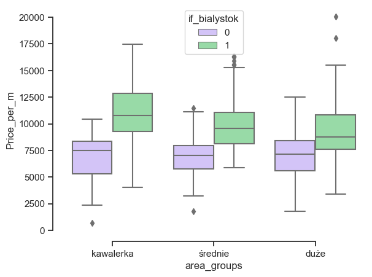

```python
sns.set_theme(style="ticks", palette="pastel")

box_data = df_without_duplicates[['Area', 'Price_per_m', 'if_bialystok']]
box_data['area_groups'] = (
    pd.cut(
        df_without_duplicates['Area'],
        np.percentile(df_without_duplicates['Area'], [0, 25, 75, 100]),
        include_lowest=True,
        labels = ['kawalerka', 'średnie', 'duże']
    )
)

# Draw a nested boxplot to show bills by day and time
sns.boxplot(x="area_groups", y="Price_per_m",
            hue="if_bialystok", palette=["m", "g"],
            data=box_data)
sns.despine(offset=10, trim=True)
```

#### 3.4.3 Przeciętna cena mieszkania za metr kwadratowy ze względu na typ oraz dzielnicę miasta

Powrót do początku

```python
district_general = (
    df_without_duplicates
    .groupby(['district_name'])
    .agg(
        n_ads= ('id', 'size'),
        mean_price_m2= ('Price_per_m', 'mean'),
        mean_area = ('Area', 'mean'),
        mean_year = ('Build_year', 'mean'),
        mean_build_flor_no = ('Building_floors_num', 'mean'),
        mean_flor_no = ('Floor_no', 'mean'),
        mean_features = ('n_features', 'mean')
    )
    .round()
    .fillna(-1)
    .astype('int')
    .sort_values(by=['mean_price_m2'], ascending=False)
    .reset_index()
)
```

```python
district_area = (
    df_without_duplicates[['Area', 'Price_per_m', 'district_name']]
    .groupby(
        [pd.cut(
            df_without_duplicates['Area'],
            np.percentile(df_without_duplicates['Area'], [0, 25, 75, 100]),
            include_lowest=True,
            labels = ['kawalerka', 'średnie', 'duże']
        ),
         'district_name']
    )
    .agg(
        mean_price = ('Price_per_m', 'mean'),
        n_ads = ('Price_per_m', 'size')
    )
    .round()
    .fillna(-1)
    .astype('int')
    .reset_index()
)

compare_df = (
    district_area
    .merge(
        district_general[['district_name', 'n_ads', 'mean_price_m2']],
        how = 'left', on = 'district_name')
    .rename(columns={
        'n_ads_x': 'n_type_ads',
        'n_ads_y': 'n_ads_in_district',
        'mean_price': 'mean_type_district_price',
        'mean_price_m2': 'mean_price_in_ddistrict'

    })
)

compare_df['type_perc_share'] = compare_df['n_type_ads'] / compare_df['n_ads_in_district']
compare_df['mean_price_diff'] = compare_df['mean_price_in_ddistrict'] - compare_df['mean_type_district_price']
display(compare_df.sort_values(['Area', 'mean_type_district_price'], ascending=False).reset_index(drop=True))
```

|  | Area | district_name | mean_type_district_price | n_type_ads | n_ads_in_district | mean_price_in_ddistrict | type_perc_share | mean_price_diff |
| --- | --- | --- | --- | --- | --- | --- | --- | --- |
| 0 | duże | Przydworcowe | 14799 | 8 | 35 | 12057 | 0.228571 | -2742 |
| 1 | duże | Dojlidy | 13560 | 1 | 1 | 13560 | 1.000000 | 0 |
| 2 | duże | Bacieczki | 10286 | 2 | 18 | 9519 | 0.111111 | -767 |
| 3 | duże | Centrum | 10277 | 27 | 209 | 11177 | 0.129187 | 900 |
| 4 | duże | Białostoczek | 10273 | 25 | 98 | 11389 | 0.255102 | 1116 |
| 5 | duże | Piaski | 10090 | 7 | 34 | 10761 | 0.205882 | 671 |
| 6 | duże | Antoniuk | 9932 | 14 | 79 | 9909 | 0.177215 | -23 |
| 7 | duże | Sienkiewicza | 9890 | 8 | 54 | 10688 | 0.148148 | 798 |
| 8 | duże | Bojary | 9870 | 15 | 65 | 10993 | 0.230769 | 1123 |
| 9 | duże | Dziesięciny | 9728 | 13 | 68 | 8972 | 0.191176 | -756 |
| 10 | duże | Bagnówka | 9550 | 6 | 12 | 9615 | 0.500000 | 65 |
| 11 | duże | Zawady | 9550 | 8 | 14 | 9846 | 0.571429 | 296 |
| 12 | duże | Wysoki Stoczek | 9533 | 16 | 56 | 9658 | 0.285714 | 125 |
| 13 | duże | Mickiewicza | 9511 | 9 | 38 | 9751 | 0.236842 | 240 |
| 14 | duże | Piasta | 9434 | 15 | 55 | 9653 | 0.272727 | 219 |
| 15 | duże | Młodych | 9375 | 7 | 32 | 9759 | 0.218750 | 384 |
| 16 | duże | Nowe Miasto | 9309 | 59 | 109 | 9872 | 0.541284 | 563 |
| 17 | duże | nan | 9308 | 49 | 241 | 10155 | 0.203320 | 847 |
| 18 | duże | Słoneczny Stok | 8117 | 2 | 16 | 8687 | 0.125000 | 570 |
| 19 | duże | Wygoda | 7993 | 38 | 93 | 9452 | 0.408602 | 1459 |
| 20 | duże | Zielone Wzgórza | 7892 | 24 | 150 | 8115 | 0.160000 | 223 |
| 21 | duże | Bema | 7749 | 5 | 24 | 9849 | 0.208333 | 2100 |
| 22 | duże | Leśna Dolina | 7748 | 10 | 30 | 8992 | 0.333333 | 1244 |
| 23 | duże | Skorupy | 7615 | 5 | 10 | 9153 | 0.500000 | 1538 |
| 24 | duże | Dojlidy Górne | 7373 | 14 | 14 | 7373 | 1.000000 | 0 |
| 25 | duże | outside | 6987 | 82 | 317 | 6934 | 0.258675 | -53 |
| 26 | duże | Starosielce | -1 | 0 | 5 | 7908 | 0.000000 | 7909 |
| 27 | średnie | Białostoczek | 11267 | 42 | 98 | 11389 | 0.428571 | 122 |
| 28 | średnie | Przydworcowe | 10867 | 18 | 35 | 12057 | 0.514286 | 1190 |
| 29 | średnie | Centrum | 10744 | 99 | 209 | 11177 | 0.473684 | 433 |

[output cut: 51 more lines]

##### 3.4.3.1 Kawalerki

Powrót do początku  
Dzielnice, w których znajduje się najwięcej kawalerek na sprzedaż to: Antoniuk, Centrum oraz osiedle Bema (około 40% mieszkań na sprzedaż w danej dzielnicy). Bagnówka, Dojlidy, Dojlidy Górne, Skorupy i Zawady - to dzielnice, w któych kawalerki nie występują. Jednakże są to dzielnice o zabudowaie jednorodzinnej i jeżeli występują tam oferty sprzedaży mieszkań to są to najprawdopodobniej szeregówki. Najmniej kawalerek występuje na Słonecznym Stoku i Wysokim Stoczku. Warto również zwrócić uwagę, że są to osiedla z przeciętnie wyższą ceną za kawalerkę. Za kawalerkę najmniej można zapłacić na Starosielcach, Zielonych Wzgórzach, Bacieczkach i Dziesięcinach. Są to też miejsca, w których stosunkowo często można znaleźć oferty sprzedaży tego typu mieszkań (od 20 do 30% wszystkich ofert w danych dzielnicach). Są to też dzielnice bardziej oddalone od centrum. Natomiast najdroższe kawalerki znajdują się w dzielnicach wokół centrum - i tam gdzie ogółem występują droższe mieszkania - Białostoczek, Sienkiewicza, Przydworcowe, Centrum i Mickiewicza. Wysoka cena kawalerki na Słonecznym Stoku jest spowodowana tym, że na tym osiedlu, w analizowanym zbiorze znaleziono tylko jedną ofertę sprzedaży tego typu mieszkania.

##### 3.4.3.2 Mieszkania średnie

Powrót do początku  
Podobnie jak w przypadku kawalerek, najdroższe mieszkania średnie można znaleźć na Białymstoczku, na osiedlu Przywdorcowym, Piaski i Centrum. Mieszkania średnie w tych dzielnicach są przeciętnie tańsze o około 1-2 tysiące złotych za metr kwadratowy. Najtańsze średniej wielkości mieszkania można znaleźć na dzielnicach oddalonych od centrum: na Zielonych Wzgórzach, Starosielcach, Dziesięcinach i Słonecznym Stoku. Oferty sprzedaży mieszkań średnich stanowią również często około 50% wszystkich ofert sprzedaży w danej dzielnicy.

##### 3.4.3.3 Mieszkania duże

Powrót do początku  
Pod kątem przeciętnej ceny za metr kwadratowy najdroższe mieszkania znaleźć można w tradycyjnie drogich dzielnicach w Białymstoku, np. na osiedlu Przydworcowym. Warto zwrócić uwagę, na to, że duże mieszkania - tj. powyżej 60 metrów kwadratowych pojawiają się częściej na dzielnicach z zabudową złożoną głównie z domów jednorodzinnych - i są to oferty sprzedaży szeregówek. Natomiast osiedle Przydworcowe jest wyjątkowe pod tym względem. Jest to osiedle, na którym za duże mieszkanie potencjalny nabywca zapłaci przeciętnie więcej za metr kwadratowy, niż za kawalerkę. Natomiast wśród pozostałych dzielnic nie obserwuje się znaczących różnic między przeciętną ceną za metr kwadratowy mieszkania pomiędzy mieszkaniami dużymi a średnimi. Największą różnicę można zaobserwować w stosunku do kawalerek (są droższe).

### 3.5 Dodatkowe cechy mieszkań na sprzedaż

Powrót do początku

Na koniec warto zwrócić uwagę na dodatkowe cechy wymienione przez ogłoszeniodawców, a które można znaleźć w oferowanych mieszkaniach na sprzedaż. Są to cechy takie jak:

- balkon
- domofon
- winda
- piwnica
- garaż/miejsce parkingowe
- internet
- telewizja kablowa
- meble
- piekarnik
- kuchenka
- lodówka
- oddzielna kuchnia
- dodatkowe pomieszczenie użytkowe
- telefon
- monitoring/ochrona
- zmywarka
- mieszkanie na terenie zamkniętym
- pralka
- drzwi / okna antywłamaniowe
- taras
- telewizor
- klimatyzacja
- ogródek
- system alarmowy
- mieszkanie dwupoziomowe
- rolety antywłamaniowe

```python
filter_col = [col for col in df_without_duplicates if col.startswith('feat_')]
filter_col.append('if_bialystok')
check_features = (
    df_without_duplicates[filter_col]
    .groupby(['if_bialystok'])
    .agg('mean')
    .round(2)
    .transpose()
    .sort_values(by=1, ascending=False)
)

display(check_features)
```

| if_bialystok | 0 | 1 |
| --- | --- | --- |
| feat_balkon | 0.49 | 0.68 |
| feat_domofon / wideofon | 0.38 | 0.53 |
| feat_winda | 0.42 | 0.46 |
| feat_piwnica | 0.29 | 0.45 |
| feat_garaż/miejsce parkingowe | 0.54 | 0.43 |
| feat_internet | 0.41 | 0.34 |
| feat_telewizja kablowa | 0.32 | 0.31 |
| feat_meble | 0.17 | 0.31 |
| feat_piekarnik | 0.13 | 0.27 |
| feat_kuchenka | 0.15 | 0.26 |
| feat_lodówka | 0.12 | 0.26 |
| feat_oddzielna kuchnia | 0.17 | 0.24 |
| feat_pom. użytkowe | 0.17 | 0.23 |
| feat_telefon | 0.33 | 0.20 |
| feat_monitoring_ochrona | 0.03 | 0.20 |
| feat_zmywarka | 0.05 | 0.18 |
| feat_teren zamknięty | 0.25 | 0.16 |
| feat_pralka | 0.08 | 0.15 |
| feat_drzwi / okna antywłamaniowe | 0.04 | 0.15 |
| feat_taras | 0.13 | 0.08 |
| feat_telewizor | 0.03 | 0.07 |
| feat_klimatyzacja | 0.01 | 0.05 |
| feat_ogródek | 0.08 | 0.05 |
| feat_dwupoziomowe | 0.02 | 0.03 |
| feat_system alarmowy | 0.01 | 0.03 |
| feat_rolety antywłamaniowe | 0.00 | 0.01 |

W Białymstoku najwięcej wystawionych mieszkań posiada dodatkowo takie cechy jak: balkon (68% wszystkich ogłoszeń), domofon, winda, piwnica i miejsce parkingowe.

Natomiast wśród mieszkań poza miastem częściej można znaleźć dodatkowe miejsce parkingowe (w 54% wszystkich ogłoszeń ), balkon (prawie 50% wszystkich ogłoszeń), winda, internet, domofon.

Interesującym zjawiskiem jest to, że w mieście częściej spotykany jest balkon niż miejsce parkingowe przypisane do danego mieszkania. Jest to konsekwencja tego, iż wokół miasta budowane są często nowe bloki już z zaplanowanymi miejscami parkingowymi i podziemnymi garażami. W mieście jest o to trudniej (różnica pomiędzy mieszkaniami w Białymstoku i poza miastem w stosunku do liczby ogłoszeń mieszkań na sprzedaż z przypisanym miejscem prakingowym to 11 punktów procentowych).

Natomiast najrzadziej występującymi dodatkowymi cechami mieszkań są rolety antywłamaniowe, klimatyzacja, system alarmowy. Chociaż warto zwrócić uwagę na klimatyzację (która częściej wystęuje w mieście niż poza nim) oraz na dodatkowy ogródek - który częściej można znaleźć wśród mieszkań poza miastem.

### 3.6 Wpływ poszczególnych cech na wartość mieszkania (przeciętna cena za metr kwadratowy)

Powrót do początku

Po przeanalizowaniu poszczególnych zmiennych w poniższej części zostanie sprawdzona ich korelacja z przeciętną cenę mieszkania za metr kwadratowy.

#### 3.6.1 Braki w danych

Powrót do początku

Mimo, iż dane zostały poddane wstępnemu przygotowaniu, nadal można zoabserwować pewne braki. Aby sprawdzić możliwie występującą korelację i odpowiedzieć na pytania badawcze - które zmienne w znaczący sposób wpływają na przeciętną cenę za metr kwadratowy - braki te należy uzupełnic. Dzięki przeprowadzonej eksploracyjnej analizie - łatwiej jest to zrobić.

Brakujące elementy zostaną podzielone według kategorii dla których zostanie przypisana przeciętna wartość według danej grupy. np: dla danych rok : przeciętny rok budowy budynku ze względu na to czy mieszkanie jest w Białymstoku czy poza. np. price per m - przeciętna cena grupy, do której przynależy dane mieszkanie - czyli, jeżel jest to kawalerka, zostanie przypisana wartość przeciętnej ceny za metr kwadratowy dla mieszkań tego typu. etc.

```python
df_without_duplicates.info()
```

```
<class 'pandas.core.frame.DataFrame'>
Int64Index: 1877 entries, 0 to 1876
Columns: 105 entries, lang to if_bialystok
dtypes: float64(10), int64(28), object(33), uint8(34)
memory usage: 1.1+ MB
```

```python
def replece_nans(x, y, df, group_col, return_var):
    if np.isnan(x) or x == -1:

        if y != 'nan':
            return(round(df[df[group_col] != -1][return_var].mean()))

        return(df[df[group_col] == y].reset_index()[return_var][0])
```

```python
district_years = (
        df_without_duplicates.groupby('district_name')
        .agg(mean_build_year = ('Build_year', 'mean'))
        .round()
        .fillna(df_without_duplicates['Build_year'].mean())
        .astype('int')
        .reset_index()
    )

df_without_duplicates['Build_year'] = [replece_nans(x, y, district_years, 'district_name',  'mean_build_year') if np.isnan(x) else x for x, y in zip(df_without_duplicates['Build_year'], df_without_duplicates['district_name'])]
```

```python
district_buildings_floor = (
        df_without_duplicates.groupby('district_name')
        .agg(mean_floor_nor = ('Building_floors_num', 'mean'))
        .round()
        .fillna(df_without_duplicates['Building_floors_num'].mean())
        .astype('int')
        .reset_index()
    )

df_without_duplicates['Building_floors_num2'] = [replece_nans(x, y, district_buildings_floor, 'district_name',  'mean_floor_nor') if np.isnan(x) else x for x, y in zip(df_without_duplicates['Building_floors_num'], df_without_duplicates['district_name'])]
```

```python
district_Floor_no = (
        df_without_duplicates.groupby('district_name')
        .agg(mean_floor_nor = ('Floor_no', 'mean'))
        .round()
        .fillna(df_without_duplicates['Floor_no'].mean())
        .astype('int')
        .reset_index()
    )

df_without_duplicates['Floor_no'] = [replece_nans(x, y, district_buildings_floor, 'district_name',  'mean_floor_nor') if np.isnan(x) else x for x, y in zip(df_without_duplicates['Floor_no'], df_without_duplicates['district_name'])]
```

```python
district_price = (
        df_without_duplicates.groupby('district_name')
        .agg(mean_price = ('Price_per_m', 'mean'))
        .round()
        .fillna(df_without_duplicates['Price_per_m'].mean())
        .astype('int')
        .reset_index()
    )

df_without_duplicates['Price_per_m'] = [replece_nans(x, y, district_price, 'district_name',  'mean_price') if np.isnan(x) else x for x, y in zip(df_without_duplicates['Price_per_m'], df_without_duplicates['district_name'])]
```

```python
feat_col = [col for col in df_without_duplicates if col.startswith('feat_')]
construction_col = [col for col in df_without_duplicates if col.startswith('construction_')]
advertiser_col = [col for col in df_without_duplicates if col.startswith('advertiser_')]
MerketType_col = [col for col in df_without_duplicates if col.startswith('MerketType_')]
district_name_col = [col for col in df_without_duplicates if col.startswith('district_')]
num_cols = ['Build_year', 'Building_floors_num', 'Floor_no', 'Area', 'if_bialystok']
predict_value = ['Price_per_m']

columnst_to_select = []
columnst_to_select = predict_value + feat_col + construction_col + advertiser_col + MerketType_col + district_name_col + num_cols

data_to_corr = df_without_duplicates[columnst_to_select]
```

```python
data_to_corr.info()
```

```
<class 'pandas.core.frame.DataFrame'>
Int64Index: 1877 entries, 0 to 1876
Data columns (total 68 columns):
 #   Column                            Non-Null Count  Dtype
---  ------                            --------------  -----
 0   Price_per_m                       1877 non-null   float64
 1   feat_piekarnik                    1877 non-null   int64
 2   feat_teren zamknięty              1877 non-null   int64
 3   feat_system alarmowy              1877 non-null   int64
 4   feat_internet                     1877 non-null   int64
 5   feat_pom. użytkowe                1877 non-null   int64
 6   feat_dwupoziomowe                 1877 non-null   int64
 7   feat_kuchenka                     1877 non-null   int64
 8   feat_ogródek                      1877 non-null   int64
 9   feat_rolety antywłamaniowe        1877 non-null   int64
```

[output cut: 60 more lines]

W danych, które zostaną poddane badaniu korelacji ze zmienną dotyczącą przeciętnej wartości metra kwadratowego, nie obserwuje się więcej braków. Można przystąpić do badania.

#### 3.6.2 Wpływ zmiennych na cenę mieszkania - analiza korelacji

Powrót do początku

Aby łatwiej czytało się tabele korelacji - poszczególne zmienne zostały podzielone na grupy i według nich utworzono 6 równych tabel. Grupy odzwierciedlają kolejność badanych zmiennych w trakcie eksploracyjnej części badania.

```python
pd.set_option('display.float_format', '{:.2f}'.format)

num_cols = ['Area', 'Build_year', 'Building_floors_num', 'Floor_no']
district_cols = [col for col in df_without_duplicates if col.startswith('district_')]
district_cols.append('if_bialystok')
construction_cols = [col for col in df_without_duplicates if col.startswith('construction_')]
MarketType_cols = [col for col in df_without_duplicates if col.startswith('MerketType_')]
advertiser_cols = [col for col in df_without_duplicates if col.startswith('advertiser_')]
features_cols = [col for col in df_without_duplicates if col.startswith('feat_')]

list_of_cols = [num_cols, district_cols, construction_cols, MarketType_cols, advertiser_cols, features_cols]

for i in list_of_cols:

    col_to_select = i
    col_to_select.append('Price_per_m')

    corr_df = (
        data_to_corr[col_to_select]
        .corr(method='pearson')['Price_per_m'].reset_index()
        .sort_values(by='Price_per_m', ascending = False)
        .reset_index(drop=True)
        .rename(columns={
            'index': 'feature',
            'Price_per_m': 'Price_per_m_corr'})
    )

    display(corr_df)
```

|  | feature | Price_per_m_corr |
| --- | --- | --- |
| 0 | Price_per_m | 1.00 |
| 1 | Building_floors_num | 0.30 |
| 2 | Build_year | 0.27 |
| 3 | Floor_no | 0.18 |
| 4 | Area | -0.22 |

|  | feature | Price_per_m_corr |
| --- | --- | --- |
| 0 | Price_per_m | 1.00 |
| 1 | if_bialystok | 0.43 |
| 2 | district_Centrum | 0.21 |
| 3 | district_Białostoczek | 0.18 |
| 4 | district_Przydworcowe | 0.15 |
| 5 | district_Bojary | 0.12 |
| 6 | district_nan | 0.10 |
| 7 | district_Sienkiewicza | 0.08 |
| 8 | district_Piaski | 0.07 |
| 9 | district_Dojlidy | 0.04 |
| 10 | district_Nowe Miasto | 0.04 |
| 11 | district_Antoniuk | 0.03 |
| 12 | district_Bema | 0.02 |
| 13 | district_Mickiewicza | 0.01 |
| 14 | district_Młodych | 0.01 |
| 15 | district_Zawady | 0.01 |
| 16 | district_Wysoki Stoczek | 0.01 |
| 17 | district_Piasta | 0.01 |
| 18 | district_Bagnówka | 0.00 |
| 19 | district_Bacieczki | -0.00 |
| 20 | district_Wygoda | -0.01 |
| 21 | district_Skorupy | -0.01 |
| 22 | district_Leśna Dolina | -0.03 |
| 23 | district_Słoneczny Stok | -0.03 |
| 24 | district_Starosielce | -0.04 |
| 25 | district_Dziesięciny | -0.04 |
| 26 | district_Dojlidy Górne | -0.08 |
| 27 | district_Zielone Wzgórza | -0.17 |
| 28 | district_outside | -0.43 |

|  | feature | Price_per_m_corr |
| --- | --- | --- |
| 0 | Price_per_m | 1.00 |
| 1 | construction_ready_to_use | 0.33 |
| 2 | construction_to_completion | -0.17 |
| 3 | construction_to_renovation | -0.26 |

|  | feature | Price_per_m_corr |
| --- | --- | --- |
| 0 | Price_per_m | 1.00 |
| 1 | MerketType_secondary | 0.08 |
| 2 | MerketType_primary | -0.08 |

|  | feature | Price_per_m_corr |
| --- | --- | --- |
| 0 | Price_per_m | 1.00 |
| 1 | advertiser_private | 0.14 |
| 2 | advertiser_business | -0.14 |

|  | feature | Price_per_m_corr |
| --- | --- | --- |
| 0 | Price_per_m | 1.00 |
| 1 | feat_zmywarka | 0.31 |
| 2 | feat_winda | 0.27 |
| 3 | feat_drzwi / okna antywłamaniowe | 0.24 |
| 4 | feat_klimatyzacja | 0.24 |
| 5 | feat_lodówka | 0.22 |
| 6 | feat_piekarnik | 0.20 |
| 7 | feat_kuchenka | 0.18 |
| 8 | feat_telewizor | 0.18 |
| 9 | feat_meble | 0.15 |
| 10 | feat_pralka | 0.14 |
| 11 | feat_balkon | 0.13 |
| 12 | feat_garaż/miejsce parkingowe | 0.12 |
| 13 | feat_system alarmowy | 0.12 |
| 14 | feat_domofon / wideofon | 0.10 |
| 15 | feat_monitoring_ochrona | 0.09 |
| 16 | feat_telewizja kablowa | 0.07 |
| 17 | feat_internet | 0.06 |
| 18 | feat_taras | 0.04 |
| 19 | feat_rolety antywłamaniowe | 0.01 |
| 20 | feat_telefon | -0.04 |
| 21 | feat_teren zamknięty | -0.04 |
| 22 | feat_ogródek | -0.04 |
| 23 | feat_piwnica | -0.05 |
| 24 | feat_dwupoziomowe | -0.06 |
| 25 | feat_pom. użytkowe | -0.06 |
| 26 | feat_oddzielna kuchnia | -0.20 |

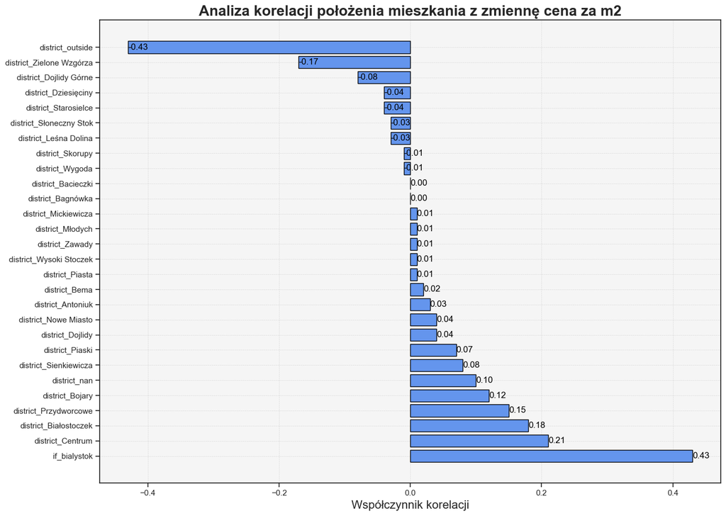

```python
# dane dotyczące współczynika korelacji dla poszczególnych dzielnic Białęgostoku
area_data_to_corr = {
    'feature': ['if_bialystok', 'district_Centrum', 'district_Białostoczek', 'district_Przydworcowe', 'district_Bojary',
                'district_nan', 'district_Sienkiewicza', 'district_Piaski', 'district_Dojlidy', 'district_Nowe Miasto', 'district_Antoniuk',
                'district_Bema', 'district_Mickiewicza', 'district_Młodych', 'district_Zawady', 'district_Wysoki Stoczek', 'district_Piasta',
                'district_Bagnówka', 'district_Bacieczki', 'district_Wygoda', 'district_Skorupy', 'district_Leśna Dolina', 'district_Słoneczny Stok',
                'district_Starosielce', 'district_Dziesięciny', 'district_Dojlidy Górne', 'district_Zielone Wzgórza', 'district_outside'],
    'Price_per_m_corr': [0.43, 0.21, 0.18, 0.15, 0.12, 0.10, 0.08, 0.07, 0.04, 0.04, 0.03, 0.02, 0.01, 0.01, 0.01, 0.01, 0.01, 0.00, -0.00, -0.01, -0.01, -0.03, -0.03, -0.04, -0.04, -0.08, -0.17, -0.43]
}

df = pd.DataFrame(area_data_to_corr)

# sortowanie wg zmiennej współczynnik korelacji
df_sorted = df.sort_values(by='Price_per_m_corr', ascending=False)

plt.figure(figsize=(14, 10))

# przygotuj bar chart
bars = plt.barh(df_sorted['feature'], df_sorted['Price_per_m_corr'], color='cornflowerblue', edgecolor='black')

# pryzgotowanie tytyłu wykresu i osi X
plt.title('Analiza korelacji położenia mieszkania z zmiennę cena za m2', fontsize=20, fontweight='bold')
plt.xlabel('Współczynnik korelacji', fontsize=16)

# dodanie etyket do wykresu
for bar in bars:
    plt.text(bar.get_width(), bar.get_y() + bar.get_height()/2, f'{bar.get_width():.2f}',
             va='center', ha='left', fontsize=12, color='black')

# przygotowanie wizualizacyjnej strony wykresu
plt.grid(True, which='both', linestyle='--', linewidth=0.5, alpha=0.7)
plt.gca().set_facecolor('whitesmoke')
plt.tight_layout()

plt.show()
```

#### 3.6.3 Podsumowanie analizy korelacji

Powrót do początku

**Dzielnica Miasta**

Zmienną, która w największym stopniu koreluje i wpływa na przeciętną cenę metra kwadratowego mieszkania na sprzedaż w Białymstoku, jest niewątpliwie umiejscowienie sprzedawanego lokalu. W danych można zaobserwować wysoki współczynnik korelacji dla mieszkań, które są umiejscowione poza granicami administracyjnymi miasta (ceny maleją) oraz dla mieszkań w mieście (ceny rosną).

Osiedle Zielone Wzgórza jest miejscem, w którym warto rozważyć zakup mieszkania. Przeciętna cena za metr kwadratowy jest mniejsza, niż w pozostałych częściach miasta. Jest to osiedle położone na uboczu, ale z dobrą drogą dojazdową do centrum i względnie dobrze dobrze funkcjonującą komunikacją miejską.

Natomiast mieszkania położone w Centrum, na osiedlu Białostoczek i osiedlu Przydworcowe będą kosztowały przeciętnie więcej, niż w innych częściach miasta. Warto zwrócić uwagę, że Białostoczek charakteryzuje się stosunkowo nowymi mieszkaniami. Przeciętny wiek sprzedawanego mieszkania na tym osiedlu to 12 lat (mimo, iż znajdują się tam również starsze bloki z okresu PRL-u to w ciągu ostatnich dwóch dekad na Białymstoczku powstało wiele nowych inwestycji). W przypadku tego osiedla warto więc zwrócić uwagę, na to, iż zmienna wiek mieszkania pozytywnie koreluje ze zmienną dotyczącą przeciętnej ceny za metr kwadratowy (im nowsze mieszkanie tym wyższa cena).

**Pozostałe zmienne**

Dodatkowe interesujące zmienne, które mają wpłw na cenę mieszkania to to, czy mieszkanie jest przygotowane już do odbioru, do wykończenia czy do kapitalnego remontu (im więcej pracy trzeba włożyć w przygotowanie mieszkanie do użytku, tym cena metra kwadratowego jest niższa). Cena także nieznacznie koreluje z tym czy mieszkanie jest z rynku pierwotnego, czy z wtórnego. Mieszkania z rynku wtórnego mogą być nieznacznie droższe, jednak są to też często mieszkania gotowe już do wprowadzenia.

Jeżeli mieszkanie jest wyposażone w dodatkowe sprzęty AGD (tj zmywarka, lodówka, piekarnik etc) - to wpłynie to na ostateczną cenę. Warto jest zwrócić też uwagę na takie cechy, jak czy do mieszkania przynależy ogród, czy jest oddzielna kuchnia, czy jest piwnica lub dodatkowe pomieszczenie gospodarcze - te zmienne wpłyną na zmniejszenie ostatecznej ceny. Jednakże, są to zmienne, które wpływają na całkowitą powierzchnię sprzedawanego mieszkania, a zmienna dotycząca powierzchni silnie oddziaływuje na ostateczną cenę - więc to tą zmienną powinno się tłumaczyć spadek ceny przy występowaniu tego typu zmiennych.

## 4. Podsumowanie badania

Powrót do początku

Zakup mieszkania to ważna, życiowa decyzja - szczególnie jeżeli jest to pierwsze mieszkanie w życiu z przeznaczeniem na cele mieszkaniowe. Wówczas cena jest jedną z zmiennych, na którą patrzy potencjalny nabwyca. Natomiast, jeżeli mieszkanie ma zostać zakupione pod cele inwestycyjne (wynajem, zakup i następnie sprzedaż z zyskiem) - wówczas nabywca będzie skupiał się na innych rzeczach, niż nabywca którego celem jest korzystanie z mieszkania na własny użytek. W obu przypadkach warto jest jednak zwrócić uwagę na to, które zmienne mogą wpływać na wzrost lub spadek ostatecznej ceny mieszkania.

### 4.1 Dzielnica

Powrót do początku

Najważniejszym pytaniem, na które powinien odpowiedzieć sobie potencjalny nabywca jest to czy chce szukać mieszkania w granicach administracyjnych miasta czy poza. Przeciętna cena metra kwadratowego dla całego zbioru to ~9.5K zł, w mieście jest to ~10K zł, poza miastem ~7K zł. Różnica jest więc znacząca. Im bliżej granic miasta tym cena wzrasta - jednakże różnica może wynosić około 2-3K zł za metr kwadratowy mieszkania. Przy wyborze mieszkania, szczególnie przy rozważaniu lokalizacji, warto jest też zwrócić uwagę na potencjalne dojazdy - istnienie komunikacji miejskiej i dróg dojazdowych. Mniejsza cena mieszkania może być atrakcyjna dla potencjalnego nabywcy, ale w dłuższej perspektywie umiejscowienie mieszkania może powodować niedogodności, jeżeli nabywca musi być np. często w centrum miasta.

Potencjalnie interesującą miejscowością do rozważenia zakupu mieszkania są Porosły (miejscowość pod Białymstokiem, około 15 min jazdy co centrum samochodem z dobrą drogą dojazdową, ale nienajlepiej funkcjonującą komunikacją publiczną). Miejscowość znajduje się przy drodze łączącej Białystok z Warszawą (S8). Jest to osiedle dynamicznie rozbudowywyujące się, z przeciętnie o 2K zł mniejszą ceną za metr kwadratowy sprzedawanego mieszkania i nowoczesnym budownictwem (przeciętny wiek sprzedawanego mieszkania to 1 rok).

Jeżeli nabywca jest zainteresowany zakupem mieszkania w granicach miasta, ale jednocześnie zależy mu na niższej niż przeciętna cenie mieszkania - powinien rozważyć mieszkanie znajdujące się na osiedlu Zielone Wzgórza. Natomiast na osiedlach takich jak Centrum, Białostoczek i Przydworcowe nabwyca zapłci około 2K zł więcej za metr kwadratowy niż na innych osiedlach. Inne osiedla warte rozważenia to osiedle Młodych, Mickiewicza, Wysoki Stoczek, Piasta. Są to duże osiedla, z przeciętnie starszą zabudową, ale blisko centrum i w których oferowane są mieszkania w niższej cenie.

### 4.2 Powierzchnia

Powrót do początku

Kolejna ważna cecha, na którą powinien zwrócić uwagę kupujący to wielkość mieszkania. Jest to zmienna, która w znaczący sposób wpływa na przeciętna cenę mieszkania za metr kwadratowy. Im większe mieszkanie, tym mniejsza cena za metr kwadratowy. Przeciętnie najdroższe są kawalerki (mieszkania do 42m2). W tym przypadku na ceną mieszkania również w znaczący sposób wpływa jego położenie (duże mieszkanie poza granicami miasta będzie się charakteryzowało zdecydowanie mniejszą przeciętną ceną za metr kwadratowy niż kawalerka w centrum).

### 4.3 Rynek pierwotny vs rynek wtórny, a status mieszkania oraz wiek budynku

Powrót do początku

Mieszkania wystawiane na sprzedaż bezpośrednio przez deweloperów charakteryzują się przeciętnie niższą ceną za metr kwadratowy, niż mieszkania z rynku wtórnego. Jednakże głębsza analiza pokazuje, że wpływ na ten stan rzeczy ma status oddawanego mieszkania (czy mieszkanie jest gotowe do wprowadzenia, do odświeżenia czy do generalnego remontu). Mieszkania, w których potrzebny jest remont niosą ze sobą dodatkowe koszta w postaci materiałów remontowych i czasu poświęconego na remont. Mieszkania oddawane przez deweloperów to najczęściej mieszkania, które muszą zostać wykończone i nie są gotowe do wprowadzenia.

Podobną korelację można zobserwować w przypadku wieku budynku - im starsze mieszkanie tym tańsze. Rok wybudowania bloku niewątpliwie ma wpływ na potencjalną cenę mieszkania. Jednakże mieszkania położone w starszych budynkach charakteryzują się często tym, że należy w nich przeprowadzić remont. Status mieszkania (czy jest to mieszkanie gotowe do wprowadzenia, do odświeżenia lub do generalnego remontu) ma zdecydowanie większy wpływ na końcową cenę mieszkania niż to, czy mieszkanie na sprzedaż zostało wystawione bezpośrednio przez dewelopera czy przez osobę prywatną. Wiek wybudowania bloku również będzie miał znaczenie, ale mniejsze niż status budynku.

### 4.4 Pozostałe zmienne

Powrót do początku

### 4.5 Liczba ogłoszeń

Powrót do początku

Na przeciętną ceną metra kwadratowego wpływa wiele zmiennych i warto przeanalizować je pod kątem tego, jakie oczekiwania ma potencajlny nabywca. Jednakże, lista nawet najlepszych cech pod zakup danego mieszkania, nie wpłynie na jego zakup, jeżeli mieszkanie nie będzie dostępne lub nie zostanie wystawione na sprzedaż. W analizowanym zbiorze danych zdecydowana większość ofert sprzedaży mieszkań dotyczyła tych, które znajdują się w granicach administracyjnych miasta Białystok (83% wszystkich analizowanych ogłoszeń). W miejscowościach tj. Porosły, Supraś, Choroszcz (miejscowości znajdujące się w okolicach miasta) - łącznie 7 % (z tego Porosłach: 3% wszystkich ogłoszeń). Potencjalny nabywca musi więc też zwrócić uwagę na podaż mieszkań w interesującej go okolicy - bowiem może mieć to wpływ na czas, jaki poświęci na szukanie interesującego go lokalu (im mniejsza liczba ogłoszeń, tym potencjalny czas poszukiwań będzie się wydłużał).

Poszukując więc idealnego mieszkania warto również jest zwrócić uwagę na liczbę ofert, które mogą się pojawiać w interesującej potencjalnego nabywcę dzielnicy. Natomiast osoby zajmujące się zawodowo sprzedażą mieszkań powinny stale obserwować liczbę ogłoszeń w danej dzielnicy tak, aby odpowiednio manipulując ceną przyciągnąć potencjalnego nabywcę lub sprzedać mieszkanie z odpowiednim zyskiem (mała liczba ogłoszeń w danym przedziale czasu na osiedlu, które charkateryzuje się interesującymi nabywców zmiennymi, może wpłynąć na podwyższenie ceny metra kwadratowego).

```python
# przygotowanie mapy na podstawie Google API maps
figure_layout = {
    'width': '100%',
    'height': '75vh',
    'border': '10px solid white',
    'padding': '2px'
}
coordinates = (53.07, 23.09)
locations = df_without_duplicates[['latitude', 'longitude']]
weights_1 = df_without_duplicates['Price_per_m']
```

[figure not shown]

## 5. Zakończenie

Powrót do początku

Zakup mieszkania to skomplikowany proces, który wymaga uwzględnienia wielu zmiennych. Cena za metr kwadratowy różni się znacząco w zależności od lokalizacji - zarówno w granicach administracyjnych miasta, jak i poza nimi. Ważne jest, aby potencjalny nabywca dokładnie przeanalizował swoje priorytety, takie jak bliskość do centrum, dostępność komunikacji miejskiej czy dynamikę rozwoju okolicy. Warto również zwrócić uwagę na stan techniczny nieruchomości oraz dodatkowe koszty związane z ewentualnym remontem. Analiza rynku pierwotnego i wtórnego może dostarczyć cennych wskazówek dotyczących opłacalności inwestycji. Niezależnie od celu zakupu - czy to na własne potrzeby mieszkaniowe, czy jako inwestycję - kluczowe jest przemyślane podejście oparte na rzetelnych danych i analizie trendów rynkowych. Powyższa analiza może pomóc w rzetelnym podjęciu decyzji, co zwiększy szanse na zadowolenie z inwestycji w długim terminie.

```python
!jupyter nbconvert "Analiza ofert sprzedaży mieszkań w Białymstoku.ipynb" --to html
```

```
[NbConvertApp] Converting notebook Analiza ofert sprzedaży mieszkań w Białymstoku.ipynb to html
[NbConvertApp] Writing 818136 bytes to Analiza ofert sprzedaży mieszkań w Białymstoku.html
```